# Chemistry of Hazardous Materials: Solids & Radiation

##### Defining Logarithmic Functions: The Inverse of Exponentiation

We now return to the logarithmic graphs in Figure Figure 24.

An **exponential function** tells us the result when we know the base and exponent. A **logarithmic function** allows us to determine the exponent when we know the base and the result.

For example:

$$2^3=8$$

In this expression:

- $2$ is the **base**.
- $3$ is the **exponent**.
- $8$ is the **result**.

But what if we know the base is 2 and the result is 8, and we want to determine the exponent?

We can rewrite the expression using a logarithm:

$$\log_2(8)=3$$

This asks: **To what power must we raise 2 to obtain 8?**

The answer is 3.

Both expressions describe the same mathematical relationship.

###### Figure 1: Definition of the Logarithmic Function

The first illustration introduces the formal definition of a logarithmic function.

$$\boxed{\log_a(x)=y\quad\Longleftrightarrow\quad a^y=x}$$

where:

- $a$ is the **base**, with $a>0$ and $a\ne1$.
- $x$ is the **positive number** whose logarithm we want to determine.
- $y$ is the **exponent** that produces $x$ when the base $a$ is raised to that power.

The symbol $\Longleftrightarrow$ means that the expressions on either side are equivalent statements.

Notice that the base $a$ does not change. We are simply expressing the same relationship in two different mathematical forms.

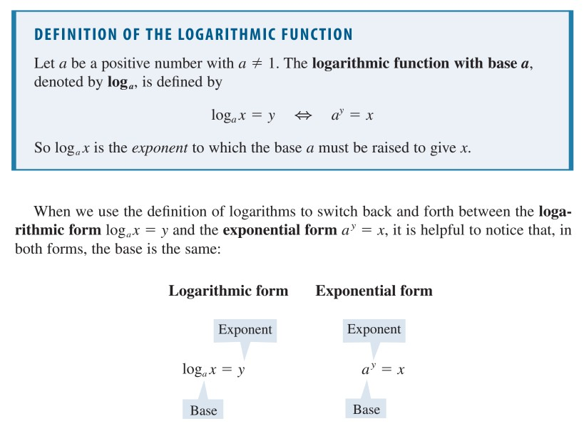

Figure 29: Definition of the logarithmic function, showing the equivalence between logarithmic and exponential notation. Source: Stewart, Redlin, and Watson, *Precalculus: Mathematics for Calculus*, 6th ed.

###### Figure 2: Identifying the Base and Exponent

Consider:

$$\log_2(8)=3$$

The logarithmic expression tells us that the base is 2 and the exponent is 3.

We can rewrite the same relationship in exponential form:

$$2^3=8$$

Notice what happens:

- The **base remains 2** in both expressions.
- The logarithm’s **result, 3**, becomes the exponent in exponential form.
- The number **8** is the value produced by raising 2 to the third power.

This relationship is useful because we can move between logarithmic and exponential forms depending on which quantity we need to determine.

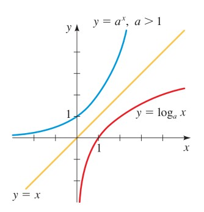

###### Figure 3: Graphing Exponential and Logarithmic Inverse Functions

The third illustration shows how exponential and logarithmic functions are related graphically.

Consider the exponential function:

$$y=2^x$$

When $x=3$:

$$y=2^3=8$$

Therefore, the point $(3,8)$ lies on the exponential graph.

Now consider its logarithmic inverse:

$$y=\log_2(x)$$

When $x=8$:

$$y=\log_2(8)=3$$

Therefore, the point $(8,3)$ lies on the logarithmic graph.

Notice that the coordinates have exchanged positions:

$$(3,8)\longleftrightarrow(8,3)$$

This occurs because exponential and logarithmic functions are **inverse functions**.

$$y=x$$

This line represents all points where the horizontal and vertical coordinates are equal.

The reflection illustrates that the input of one function becomes the output of its inverse.

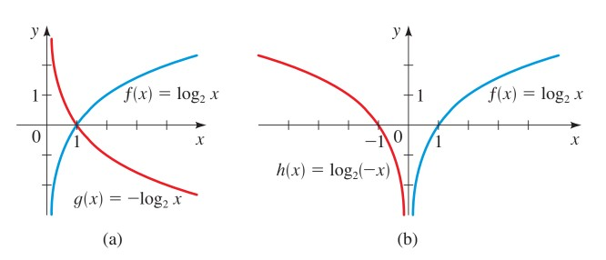

**NoteWhy Is This Useful?**

An exponential function allows us to calculate a result when the exponent is known.

A logarithmic function allows us to determine the exponent when the result is known.

This distinction becomes important when studying radioactive decay.

For example, if we know the initial mass of a radioactive isotope, its half-life, and the elapsed time, we can calculate how much material remains using an exponential function.

But what if we know the initial mass and the remaining mass, and want to determine **how much time has elapsed**?

Because time appears in the exponent of the radioactive decay equation, logarithms allow us to isolate and calculate that unknown time.

##### Euler’s Number and the Natural Exponential Function

So far, we have examined exponential functions with bases such as 2, 3, and $1/2$. Another important base is **Euler’s number**, represented by the letter $e$:

$$e\approx2.71828$$

Euler’s number is a mathematical constant, just like $\pi$. Its value does not change.

But why is this particular number useful?

Euler’s number appears naturally in mathematics used to describe **continuous growth and decay**. Examples include population growth, continuously compounded interest, heat transfer, and radioactive decay.

Although we can describe exponential changes using many different bases, using $e$ makes the mathematics of continuous rates of change particularly convenient.

The **natural exponential function** is defined by:

$$\boxed{f(x)=e^x}$$

where:

- $e$ is Euler’s number, approximately 2.71828.
- $x$ is the exponent, or independent variable.
- $f(x)$ is the output of the function.

###### Figure 1: Comparing Exponential Functions

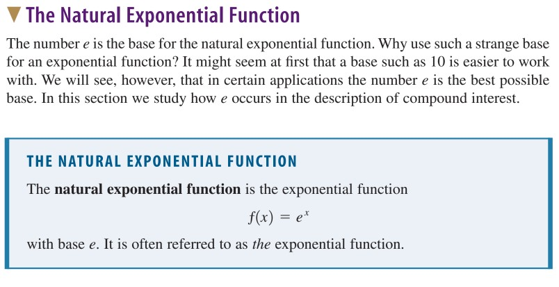

The natural exponential function belongs to the same family of exponential functions we examined earlier:

$$f(x)=a^x$$

The difference is that its base is $e$, rather than 2, 3, or another positive number.

For example:

$$e^0=1$$

$$e^1\approx2.71828$$

$$e^2\approx7.38906$$

Like other exponential functions with a base greater than 1, $e^x$ increases as $x$ increases.

The important distinction is not that (e^x) grows while other exponential functions do not. It is that the base (e) is especially useful when modeling continuous changes.

###### Figure 2: Why Euler’s Number Is Useful

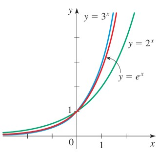

Figure 33: Graph illustrating the behavior of the natural exponential function. Source: Stewart, Redlin, and Watson, *Precalculus: Mathematics for Calculus*, 6th ed., Section 4.2.

Consider a process in which the rate of change depends on how much of a quantity is currently present.

For example:

- A growing population may increase faster when more individuals are present.
- A radioactive sample with more unstable nuclei will generally experience more radioactive decays per unit time than a smaller sample of the same isotope.
- A warmer object may cool faster when the temperature difference between the object and its surroundings is larger.

These processes can be described using exponential models.

Euler’s number is particularly useful because the function $e^x$ has a special mathematical property: **its instantaneous rate of change is equal to its current value**.

In calculus, this means that the derivative of $e^x$ is also $e^x$.

We do not need to calculate derivatives in this course. What matters is recognizing why scientists frequently use Euler’s number when describing quantities that change continuously.

###### Figure 3: Exponential Growth Versus Exponential Decay

The third illustration compares two functions:

$$f(x)=e^x$$

and

$$f(x)=e^{-x}$$

Although both functions use Euler’s number as their base, their behavior differs.

- $e^x$ represents exponential growth: the output increases as $x$ increases.
- $e^{-x}$ represents exponential decay: the output decreases as $x$ increases.

Recall that a negative exponent represents a reciprocal:

$$e^{-x}=\frac{1}{e^x}$$

For example, when $x=1$:

$$e^{-1}=\frac{1}{e}\approx0.36788$$

When $x=2$:

$$e^{-2}=\frac{1}{e^2}\approx0.13534$$

The output becomes progressively smaller as $x$ increases.

Notice that the decreasing function remains positive and approaches zero without reaching it.

This is the mathematical behavior we will use to describe radioactive decay.

**NoteWhy Is This Useful?**

Radioactive decay is a continuous process in which unstable atomic nuclei undergo nuclear transformations.

For a sufficiently large sample of a single radioactive isotope, the expected rate of decay is proportional to the number of radioactive nuclei remaining.

As the number of radioactive nuclei decreases, the expected number of decays per unit time also decreases.

Following Stewart, Redlin, and Watson, we can describe the remaining mass of a radioactive substance using the **radioactive decay model**:

$$\boxed{m(t)=m_0e^{-rt}}$$

where:

- $m(t)$ is the mass of the radioactive substance remaining after elapsed time $t$.
- $m_0$ is the initial mass of the radioactive substance.
- $e$ is Euler’s number, approximately 2.71828.
- $r$ is the **positive radioactive decay constant**.
- $t$ is the elapsed time.

The decay constant is related to the radioactive substance’s half-life by:

$$\boxed{r=\frac{\ln 2}{h}}$$

where:

- $r$ is the positive radioactive decay constant.
- $\ln 2$ is the natural logarithm of 2, approximately 0.69315.
- $h$ is the half-life of the radioactive substance, expressed in the same time units used for $t$.

Because $r$ is positive, the exponent $-rt$ becomes more negative as time increases, causing the remaining mass to decrease.

**The practical advantage:** Once we know the initial mass and half-life of a radioactive substance, we can calculate its decay constant and estimate how much material remains after a specified period.

Later, we will use this relationship to solve radioactive decay problems involving half-life, remaining mass, and elapsed time.

##### Natural Logarithms: The Inverse of the Natural Exponential Function

So far, we have learned that logarithmic functions allow us to reverse exponential relationships and determine an unknown exponent.

When the base of an exponential function is Euler’s number, $e$, its inverse is called the **natural logarithm**.

The natural logarithm is written $\ln$:

$$\boxed{\ln(x)=\log_e(x)}$$

where:

- $\ln(x)$ is the natural logarithm of $x$.
- $e$ is Euler’s number, approximately 2.71828.
- $x$ is a positive number, with $x>0$.

Unlike logarithms with bases such as 2 or 10, natural logarithms specifically use Euler’s number as their base.

###### Figure 1: Defining the Natural Logarithm

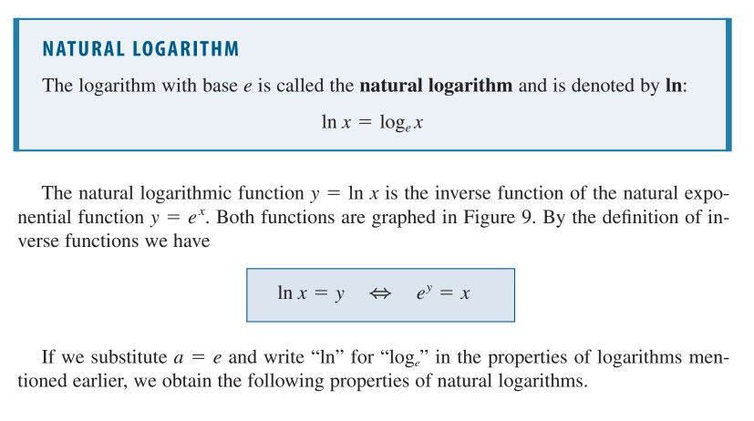

Figure 35: Definition of the natural logarithm. Source: Stewart, Redlin, and Watson, *Precalculus: Mathematics for Calculus*, 6th ed., Section 4.3.

The natural logarithm and natural exponential function are **inverse functions**.

In Stewart’s notation:

$$\boxed{\ln(x)=y\quad\Longleftrightarrow\quad e^y=x}$$

where:

- $x$ is the positive number whose natural logarithm we want to determine.
- $y$ is the exponent.
- $e$ is the base of the exponential function.

This means that $\ln(x)$ asks:

**To what power must we raise** $e$ to obtain $x$?

For example:

$$e^2\approx7.38906$$

Therefore:

$$\boxed{\ln(e^2)=2}$$

We recover the exponent 2 because the natural logarithm reverses exponentiation with base $e$.

###### Figure 2: Properties of Natural Logarithms

[figure not shown]

Because the natural logarithm and natural exponential function are inverses, they can reverse one another’s operations.

Two important relationships are:

$$\boxed{\ln(e^x)=x}$$

and, for $x>0$:

$$\boxed{e^{\ln(x)}=x}$$

The first relationship tells us that taking the natural logarithm of an exponential expression with base $e$ returns the original exponent.

The second relationship tells us that raising $e$ to the natural logarithm of a positive number returns the original number.

For example:

$$\ln(1)=0$$

**Why does the natural logarithm equal zero?**

Because raising Euler’s number to the zeroth power produces 1:

$$e^0=1$$

Similarly:

$$\ln(e)=1$$

**Why does the natural logarithm equal one?**

Because raising Euler’s number to the first power produces $e$:

$$e^1=e$$

In both examples, the natural logarithm tells us the exponent needed to produce the number inside the parentheses.

###### Figure 3: Graphing Natural Logarithms and Their Inverses

[figure not shown]

The natural exponential function is:

$$y=e^x$$

Its inverse is:

$$y=\ln(x)$$

Just as we observed with other exponential and logarithmic functions, these graphs are reflections of one another across the diagonal line:

$$y=x$$

Consider the exponential function:

$$e^0=1$$

This tells us that the point $(0,1)$ lies on the graph of $y=e^x$.

For the inverse function:

$$\ln(1)=0$$

The corresponding point is $(1,0)$ on the graph of $y=\ln(x)$.

Notice how the coordinates exchange positions:

$$(0,1)\longleftrightarrow(1,0)$$

This illustrates how an inverse function reverses the roles of the input and output.

**NoteWhy Is This Useful?**

Recall Stewart’s radioactive decay model:

$$\boxed{m(t)=m_0e^{-rt}}$$

where:

- $m(t)$ is the mass of the radioactive parent isotope remaining after elapsed time $t$.
- $m_0$ is the initial mass of the radioactive parent isotope.
- $e$ is Euler’s number.
- $r$ is the positive radioactive decay constant.
- $t$ is elapsed time.

If we know the initial mass, decay constant, and elapsed time, we can calculate the remaining mass.

But what if we know the initial mass and remaining mass and want to determine **how much time has passed**?

Because time appears in the exponent, we can use the natural logarithm to reverse the exponential relationship.

This is why natural logarithms are particularly useful in radioactive decay calculations.

Later, we will apply this inverse relationship to solve for elapsed time using Stewart’s radioactive decay model.

##### Understanding the Laws of Logarithms

Logarithms follow rules that allow us to simplify expressions and solve equations. For positive numbers $a$ and $b$, and any real exponent $x$:

**Product law**

$$\ln(ab)=\ln(a)+\ln(b)$$

**Quotient law**

$$\ln\left(\frac ab\right)=\ln(a)-\ln(b)$$

**Power law**

$$\ln(a^x)=x\ln(a)$$

The power law is especially important because it allows an exponent to be written as a multiplier. For example:

$$\ln(2^3)=3\ln(2)=\ln(8)\approx2.07944$$

When the base is $e$, the expression simplifies further:

$$\ln(e^3)=3\ln(e)=3(1)=3$$

This is why the natural logarithm is useful for solving an equation with an unknown exponent. We will use the same operation later to determine elapsed time from the amount of radioactive material remaining.

**NoteWhy Is This Useful?**

A linear equation can often be solved using addition, subtraction, multiplication, and division. An exponential equation is different because the unknown may appear **in the exponent**.

Logarithms allow us to reverse exponentiation and isolate that unknown. For radioactive decay, this means we can use measurements of the amount remaining to determine **how much time has elapsed**, provided the decay model and its parameters are known.

#### Understanding Radioactive Half-Life

**Physical half-life:** The time required for half of a large population of radioactive parent nuclei to undergo radioactive decay.

For example, suppose a radioactive sample initially contains 300 mg of a particular radioactive isotope.

If its half-life is 140 days, then approximately half of the original isotope remains after 140 days.

$$300\ \mathrm{mg}\times\frac12=150\ \mathrm{mg}$$

After another 140 days, half of the remaining 150 mg will have decayed.

$$150\ \mathrm{mg}\times\frac12=75\ \mathrm{mg}$$

After a third half-life:

$$75\ \mathrm{mg}\times\frac12=37.5\ \mathrm{mg}$$

Notice that we multiply by $\frac12$ each time.

**Why do we use** $\frac12$?

Because half-life means that half of the radioactive parent material remains after each half-life.

We can represent repeated multiplication using exponents.

After one half-life:

$$300\left(\frac12\right)^1=150$$

After two half-lives:

$$300\left(\frac12\right)^2=75$$

After three half-lives:

$$300\left(\frac12\right)^3=37.5$$

The exponent tells us how many half-lives have elapsed.

##### Developing the Half-Life Equation

We can now describe this pattern mathematically:

$$m(t)=m_0\left(\frac12\right)^{t/h}$$

where:

- $m(t)$ is the mass of the radioactive parent isotope remaining after time $t$.
- $m_0$ is the initial mass of the radioactive parent isotope.
- $\frac12$ is the fraction remaining after one half-life.
- $t$ is elapsed time.
- $h$ is the physical half-life.
- $t/h$ is the number of elapsed half-lives.

The time variables $t$ and $h$ must use the same units.

For example, if 280 days have elapsed and the half-life is 140 days:

$$\frac{t}{h}
=
\frac{280\ \mathrm{days}}{140\ \mathrm{days}}
=2$$

Two half-lives have elapsed.

Therefore:

$$m(280)=300\left(\frac12\right)^2$$

$$m(280)=300\left(\frac14\right)$$

$$\boxed{m(280)=75\ \mathrm{mg}}$$

We have calculated the remaining mass using the physical meaning of half-life.

#### Why Radioactive Decay Is Exponential

Radioactive decay is not a linear process.

The amount of radioactive parent material decreases by the same fraction over each half-life, rather than by the same mass.

The half-life equation is one way to describe this process.

Another way uses the natural exponential function:

$$\boxed{m(t)=m_0e^{-rt}}$$

where:

- $m(t)$ is the mass of the radioactive parent isotope remaining after time $t$.
- $m_0$ is the initial mass of the radioactive parent isotope.
- $e$ is Euler’s number.
- $r$ is the positive radioactive decay constant, expressed in inverse time units.
- $t$ is elapsed time.

**Why is there a negative sign in the exponent?**

Consider the exponential part of the equation:

$$e^{-rt}$$

Because $r>0$, the exponent becomes more negative as time increases.

For example, consider the values of the natural exponential function:

$$e^0=1$$

$$e^{-1}\approx0.368$$

$$e^{-2}\approx0.135$$

As the exponent becomes more negative, the exponential factor decreases.

This represents the decreasing mass of radioactive parent material.

##### Connecting the Decay Constant to Half-Life

We have introduced two mathematical equations that describe the exponential decay of radioactive parent material:

**1. Half-life equation**

$$m(t)=m_0\left(\frac{1}{2}\right)^{t/h}$$

**2. Natural exponential decay equation**

$$m(t)=m_0e^{-rt}$$

Both equations describe the mass of radioactive parent material remaining after an elapsed time $t$. However, they express the rate of decay differently.

The first equation uses the **physical half-life (**$h$), while the second uses the **radioactive decay constant (**$r$).

Our objective is to determine how these two quantities are mathematically related.

For this derivation:

- $m(t)$ is the mass of radioactive parent material remaining at elapsed time $t$.
- $m_0$ is the initial mass of radioactive parent material.
- $t$ is elapsed time.
- $h$ is the physical half-life of the radioactive isotope.
- $r$ is the radioactive decay constant, expressed in inverse units of time.
- $e$ is Euler’s number, approximately $2.71828$.

**Step 1: Establish the condition of one half-life.**

The physical half-life is the time required for half of the radioactive parent nuclei in a large sample to undergo radioactive decay.

If the elapsed time is equal to one physical half-life, then:

$$t=h$$

For example, suppose a radioactive isotope has a physical half-life of 140 days.

After one half-life has elapsed:

$$t=h=140\ \mathrm{days}$$

We can now use this condition to evaluate both exponential decay equations at the same point in time.

**Step 2: Substitute the half-life into the half-life equation.**

Begin with the half-life equation:

$$m(t)=m_0\left(\frac{1}{2}\right)^{t/h}$$

Since we are evaluating the remaining mass after one half-life, substitute $t=h$:

$$m(h)=m_0\left(\frac{1}{2}\right)^{h/h}$$

Notice that the function notation changes from $m(t)$ to $m(h)$ because we are calculating the remaining mass when the elapsed time equals one half-life.

The exponent is:

$$\frac{h}{h}=1$$

For our example:

$$\frac{140\ \mathrm{days}}{140\ \mathrm{days}}=1$$

Therefore:

$$m(h)=m_0\left(\frac{1}{2}\right)^1$$

Any number raised to the first power equals itself:

$$\left(\frac{1}{2}\right)^1=\frac{1}{2}$$

Thus:

$$m(h)=m_0\left(\frac{1}{2}\right)$$

Multiplying by one-half is equivalent to dividing by two:

$$\begin{aligned}
m(h)
&=m_0\left(\frac{1}{2}\right)\\[6pt]
&=\frac{m_0\times1}{2}\\[6pt]
&=\frac{m_0}{2}
\end{aligned}$$

We have demonstrated mathematically that:

$$\boxed{m(h)=\frac{m_0}{2}}$$

This confirms the definition of half-life: after one physical half-life, half of the original radioactive parent material remains.

For example, if the initial mass were 300 mg:

$$m(h)=\frac{300\ \mathrm{mg}}{2}=150\ \mathrm{mg}$$

**Step 3: Apply the same condition to the natural exponential decay equation.**

We will now use the second equation to describe the same radioactive material at the same elapsed time.

Begin with:

$$m(t)=m_0e^{-rt}$$

Recall that one half-life has elapsed when:

$$t=h$$

Substitute $h$ for $t$:

$$m(h)=m_0e^{-rh}$$

This equation describes the remaining mass after one half-life using the radioactive decay constant $r$.

From Step 2, we already established that:

$$m(h)=\frac{m_0}{2}$$

Both expressions represent the mass remaining after the same elapsed time.

Therefore, we can set them equal:

$$\boxed{\frac{m_0}{2}=m_0e^{-rh}}$$

We now have an equation containing both the physical half-life $h$ and the radioactive decay constant $r$.

Our next objective is to isolate $r$.

**Step 4: Divide both sides by the initial mass.**

Begin with:

$$\frac{m_0}{2}=m_0e^{-rh}$$

To isolate the exponential expression, divide both sides by $m_0$:

$$\frac{\frac{m_0}{2}}{m_0}
=
\frac{m_0e^{-rh}}{m_0}$$

Because the initial mass $m_0$ is the same nonzero quantity on both sides, it cancels:

$$\frac{\frac{\cancel{m_0}}{2}}{\cancel{m_0}}
=
\frac{\cancel{m_0}e^{-rh}}{\cancel{m_0}}$$

We obtain:

$$\boxed{\frac{1}{2}=e^{-rh}}$$

This equation tells us that after one half-life, the natural exponential factor must equal one-half.

**Step 5: Apply the natural logarithm to both sides.**

We need to solve for $r$, but it is currently located in the exponent:

$$\frac{1}{2}=e^{-rh}$$

Recall that the natural logarithm is the inverse function of the natural exponential function.

We can use this inverse relationship to remove the exponential function and isolate the exponent.

Take the natural logarithm of both sides:

$$\ln\left(\frac{1}{2}\right)=\ln\left(e^{-rh}\right)$$

Recall the inverse relationship:

$$\ln(e^x)=x$$

In our equation, the exponent $x$ is equal to $-rh$.

Therefore:

$$\ln\left(e^{-rh}\right)=-rh$$

Substituting this result gives:

$$\boxed{\ln\left(\frac{1}{2}\right)=-rh}$$

We have removed the exponential function and obtained an equation that we can solve algebraically for $r$.

**Step 6: Isolate the radioactive decay constant.**

Begin with:

$$\ln\left(\frac{1}{2}\right)=-rh$$

Because $r$ is multiplied by $-h$, divide both sides by $-h$:

$$\frac{\ln(1/2)}{-h}
=
\frac{-rh}{-h}$$

The factor $-h$ cancels on the right-hand side:

$$\frac{\ln(1/2)}{-h}
=
\frac{r\cancel{(-h)}}{\cancel{(-h)}}$$

Therefore:

$$r=\frac{\ln(1/2)}{-h}$$

We can also express this as:

$$\boxed{r=-\frac{\ln(1/2)}{h}}$$

However, we can simplify the logarithmic expression further.

**Step 7: Simplify the logarithm using logarithmic identities.**

Recall the quotient rule for logarithms:

$$\ln\left(\frac{a}{b}\right)=\ln(a)-\ln(b)$$

Apply this rule to the fraction $\frac{1}{2}$:

$$\ln\left(\frac{1}{2}\right)=\ln(1)-\ln(2)$$

Recall that:

$$e^0=1$$

Therefore:

$$\ln(1)=0$$

Substitute this value:

$$\begin{aligned}
\ln\left(\frac{1}{2}\right)
&=\ln(1)-\ln(2)\\[6pt]
&=0-\ln(2)\\[6pt]
&=-\ln(2)
\end{aligned}$$

Return to our expression for the decay constant:

$$r=-\frac{\ln(1/2)}{h}$$

Substitute $\ln(1/2)=-\ln(2)$:

$$r=-\frac{-\ln(2)}{h}$$

The two negative signs produce a positive result:

$$\boxed{r=\frac{\ln(2)}{h}}$$

We have now derived the mathematical relationship between the radioactive decay constant and the physical half-life.

This equation is called the **half-life–decay constant relationship**.

It allows us to calculate the radioactive decay constant ($r$) when we know the physical half-life ($h$).

Because:

$$\ln(2)\approx0.693147$$

We can also write:

$$\boxed{r\approx\frac{0.693147}{h}}$$

The units of $r$ are the inverse of the time units used for $h$.

For example, if $h$ is measured in days, then $r$ is expressed in $\mathrm{days}^{-1}$.

**Step 8: Interpret the positive decay constant and negative exponent.**

Our derivation gives:

$$r=\frac{\ln(2)}{h}$$

Since $\ln(2)>0$ and the physical half-life $h>0$, the radioactive decay constant is positive:

$$r>0$$

However, recall that the natural exponential decay equation contains a negative sign:

$$m(t)=m_0e^{-rt}$$

**Why does the equation use a negative sign if the decay constant is positive?**

The negative sign in the exponent indicates that the amount of radioactive parent material decreases over time.

As elapsed time ($t$) increases, the exponent $-rt$ becomes increasingly negative.

For example:

$$e^0=1$$

$$e^{-1}\approx0.368$$

$$e^{-2}\approx0.135$$

As the exponent becomes more negative, the exponential factor decreases toward zero.

- $r>0$: The radioactive decay constant is positive.
- $-rt$: The negative sign gives the exponential function its decreasing direction.
- $e^{-rt}$: The fraction of radioactive parent material remaining decreases as time increases.

The negative sign does not mean that the decay constant or remaining mass is negative. It describes the direction of the exponential change.

#### First-Order Radioactive Decay

Radioactive decay follows a **first-order process**, meaning that the rate of decay is directly proportional to the number of radioactive parent nuclei remaining.

In simpler terms, the more radioactive parent nuclei present, the more nuclear transformations we expect to occur per unit time. As the number of parent nuclei decreases, the activity of the parent isotope also decreases.

An important characteristic of first-order radioactive decay is that **the physical half-life depends on the radioactive decay constant, not on the initial amount of radioactive material**.

Recall the half-life–decay constant relationship:

$$r=\frac{\ln(2)}{h}$$

Therefore:

- **A larger decay constant (**$r$) corresponds to a shorter physical half-life and more rapid radioactive decay.
- **A smaller decay constant (**$r$) corresponds to a longer physical half-life and slower radioactive decay.

The physical half-life of a particular radioactive isotope remains the same regardless of the initial mass of the sample.

##### How Is Radioactive Decay Different From Ordinary Chemical Reactions?

The rates of many ordinary chemical reactions can change with environmental conditions, including temperature, pressure, and reactant concentrations.

Radioactive decay is different because it involves transformations of unstable atomic nuclei rather than the rearrangement of chemical bonds.

For a particular radioactive isotope, the decay constant and physical half-life are generally unaffected by ordinary changes in temperature and pressure.

This means that changing the storage conditions of radioactive material will not ordinarily accelerate its nuclear decay.

**NoteApplication to Hazardous Materials Management**

Understanding radioactive decay is important when planning the storage, handling, and long-term management of radioactive materials.

The **physical half-life** helps us estimate how much radioactive parent material remains after a specified period.

The **radioactive decay constant** characterizes how rapidly radioactive nuclei undergo decay and helps us understand how the activity of a radioactive source changes over time.

These properties are particularly important when considering radioactive waste storage and decay-in-storage practices.

However, **radioactive decay alone does not determine whether a material is safe to handle or dispose of**. Radiation type, energy, activity, radioactive daughter products, exposure pathways, shielding, and applicable regulatory requirements must also be considered.

#### Why Do We Need Two Radioactive Decay Equations?

We have learned two equations that describe the same radioactive decay process:

**Half-life equation**

$$m(t)=m_0\left(\frac{1}{2}\right)^{t/h}$$

**Natural exponential decay equation**

$$m(t)=m_0e^{-rt}$$

If both equations calculate the same remaining mass, why do we need to learn both?

The **half-life equation** is useful when we know the physical half-life of a radioactive isotope and want to calculate how much radioactive parent material remains after a given period.

The **natural exponential decay equation** describes the same process using the radioactive decay constant ($r$), which characterizes how rapidly radioactive nuclei undergo decay.

The decay constant also connects the number of radioactive parent nuclei remaining to the radioactive activity of a sample:

$$A=rN$$

where:

- $A$ is radioactive activity, or the number of nuclear transformations occurring per unit time.
- $r$ is the radioactive decay constant.
- $N$ is the number of radioactive parent nuclei remaining.

The two equations are mathematically equivalent, and the relationship:

$$\boxed{r=\frac{\ln(2)}{h}}$$

allows us to convert between physical half-life and the radioactive decay constant.

**For hazardous materials management, half-life helps us understand how long radioactive parent material persists, while the decay constant characterizes how rapidly its nuclei undergo decay.**

Neither quantity alone establishes the radiation dose or health risk associated with a radioactive material.

#### Worked Example: Radioactive Decay of Polonium-210

*Mathematical approach based on Stewart, Redlin, and Watson, Precalculus: Mathematics for Calculus, 6th ed., Section 4.6, Example 6.*

You have 300 mg of polonium-210. The physical half-life is 140 days. One year has passed. How much polonium-210 is left after one-year? What is the rate of natural decay for polonium-210? How many days until 200 mg of polonium-210 remains?

For this example, we will use a half-life of 140 days. This is a rounded instructional value; the measured physical half-life of polonium-210 is approximately 138.4 days.

We want to answer three questions:

1. How much polonium-210 remains after 365 days?
2. What is the radioactive decay constant?
3. How much time must pass before only 200 mg remain?

##### Part I: How Much Radioactive Material Remains?

**Step 1: Identify the known information, unknown variable, and relevant equations.**

Before beginning a calculation, we need to identify the information provided in the problem and determine what we are trying to calculate.

**Known information:**

Initial mass of the radioactive parent isotope:

$$m_0=300\ \mathrm{mg}$$

Physical half-life:

$$h=140\ \mathrm{days}$$

Elapsed time:

$$t=365\ \mathrm{days}$$

**Unknown variable:**

We want to calculate the mass of radioactive parent material remaining after 365 days:

$$m(t)=?$$

**Relevant equations:**

We have learned two equations that describe the remaining mass of radioactive parent material and a third equation that relates the physical half-life to the radioactive decay constant.

**1. Half-life equation**

$$m(t)=m_0\left(\frac{1}{2}\right)^{t/h}$$

**2. Natural exponential decay equation**

$$m(t)=m_0e^{-rt}$$

**3. Half-life–decay constant relationship**

$$r=\frac{\ln(2)}{h}$$

where:

- $m(t)$ is the mass of radioactive parent material remaining after elapsed time $t$.
- $m_0$ is the initial mass of radioactive parent material.
- $t$ is elapsed time.
- $h$ is the physical half-life of the radioactive isotope.
- $r$ is the radioactive decay constant, expressed in inverse units of time.
- $e$ is Euler’s number, approximately $2.71828$.
- $\ln$ represents the natural logarithm.

The **half-life equation** and **natural exponential decay equation** can both be used to calculate the remaining mass of radioactive parent material.

The **half-life–decay constant relationship** allows us to calculate the radioactive decay constant ($r$) from the known physical half-life ($h$).

The information provided in a problem helps us determine which equation, or combination of equations, to use.

**Step 2: Select the appropriate equation.**

We know the initial mass ($m_0$), physical half-life ($h$), and elapsed time ($t$).

Our unknown is the remaining mass, $m(t)$.

Consider the three equations identified in Step 1.

| Equation | Mathematical Expression | Required Information | Application to Our Problem |
| --- | --- | --- | --- |
| **1. Half-life equation** | $m(t)=m_0\left(\frac{1}{2}\right)^{t/h}$ | Initial mass ($m_0$), elapsed time ($t$), and physical half-life ($h$) | **All three values are known.** We can calculate the remaining mass directly. |
| **2. Natural exponential decay equation** | $m(t)=m_0e^{-rt}$ | Initial mass ($m_0$), elapsed time ($t$), and radioactive decay constant ($r$) | We know $m_0$ and $t$, but must first calculate $r$. |
| **3. Half-life–decay constant relationship** | $r=\frac{\ln(2)}{h}$ | Physical half-life ($h$) | We can calculate $r$ and then use Equation 2 to determine the remaining mass. |

**Which equation should we select?**

Because the physical half-life is already provided, the most direct approach is to use the **half-life equation**:

$$\boxed{m(t)=m_0\left(\frac{1}{2}\right)^{t/h}}$$

This equation allows us to calculate the remaining mass directly without first calculating the radioactive decay constant.

In Part II, we will use the half-life–decay constant relationship and the natural exponential decay equation to solve the same problem using a different approach.

**Which equation should we select?**

Because the physical half-life is already provided, the most direct approach is to use the **half-life equation**:

$$\boxed{m(t)=m_0\left(\frac{1}{2}\right)^{t/h}}$$

This equation allows us to calculate the remaining mass directly without first calculating the radioactive decay constant.

In Part II, we will use the half-life–decay constant relationship and the natural exponential decay equation to solve the same problem using a different approach.

**Step 3: Substitute the known values.**

Begin with:

$$m(t)=m_0\left(\frac{1}{2}\right)^{t/h}$$

Substitute the initial mass, elapsed time, and physical half-life:

$$m(365)=(300\ \mathrm{mg})
\left(\frac{1}{2}\right)^{365/140}$$

**Step 4: Calculate the exponent.**

$$\frac{365}{140}\approx2.60714$$

This means approximately 2.61 half-lives have elapsed.

**Step 5: Evaluate the exponential expression.**

$$\left(\frac{1}{2}\right)^{365/140}\approx0.164124$$

This means approximately 16.41% of the original polonium-210 remains.

**Step 6: Calculate the remaining mass.**

$$m(365)\approx(300\ \mathrm{mg})(0.164124)$$

Therefore:

$$\boxed{m(365)\approx49.24\ \mathrm{mg}}$$

Approximately 49.24 mg of polonium-210 remains after 365 days using the assumed physical half-life of 140 days.

##### Part II: Calculate the Radioactive Decay Constant and Apply the Natural Exponential Decay Equation

In Part I, we used the half-life equation to calculate how much radioactive parent material remains after 365 days.

We will now solve the same problem using the **half-life–decay constant relationship** and the **natural exponential decay equation**.

Our known information is:

- Initial mass: $m_0=300\ \mathrm{mg}$
- Physical half-life: $h=140\ \mathrm{days}$
- Elapsed time: $t=365\ \mathrm{days}$

Our objective is to calculate the radioactive decay constant ($r$) and use it to determine the remaining mass, $m(365)$.

**Step 1: Calculate the radioactive decay constant (**$r$).

Recall the half-life–decay constant relationship:

$$r=\frac{\ln(2)}{h}$$

Substitute the physical half-life:

$$r=\frac{\ln(2)}{140\ \mathrm{days}}$$

Recall that:

$$\ln(2)\approx0.693147$$

Therefore:

$$r\approx\frac{0.693147}{140\ \mathrm{days}}$$

Divide:

$$\boxed{r\approx0.00495105\ \mathrm{days}^{-1}}$$

Because the half-life is expressed in days, the radioactive decay constant is expressed in inverse days ($\mathrm{days}^{-1}$).

**Step 2: Identify the natural exponential decay equation.**

Recall:

$$\boxed{m(t)=m_0e^{-rt}}$$

where:

- $m(t)$ is the remaining mass of radioactive parent material.
- $m_0$ is the initial mass of radioactive parent material.
- $r$ is the radioactive decay constant.
- $t$ is the elapsed time.
- $e$ is Euler’s number, approximately $2.71828$.

We now have all the information needed to calculate the remaining mass.

**Step 3: Substitute the known values and solve.**

Substitute:

$$m(365)=(300\ \mathrm{mg})
e^{-(0.00495105\ \mathrm{days}^{-1})(365\ \mathrm{days})}$$

Notice that the time units cancel:

$$\mathrm{days}^{-1}\times\mathrm{days}=1$$

The exponent is dimensionless, meaning it has no units.

Calculate the exponent:

$$-(0.00495105)(365)\approx-1.80713$$

Therefore:

$$m(365)\approx(300\ \mathrm{mg})e^{-1.80713}$$

Evaluate the exponential factor:

$$e^{-1.80713}\approx0.1641$$

Multiply by the initial mass:

$$m(365)\approx(300\ \mathrm{mg})(0.1641)$$

Using the unrounded values in the calculation:

$$\boxed{m(365)\approx49.23\ \mathrm{mg}}$$

After 365 days, approximately **49.23 mg of the original 300 mg of polonium-210 remains**.

**Compare the results from Parts I and II.**

In Part I, we used the half-life equation:

$$m(t)=m_0\left(\frac{1}{2}\right)^{t/h}$$

In Part II, we used the natural exponential decay equation:

$$m(t)=m_0e^{-rt}$$

Both approaches give approximately:

$$\boxed{m(365)\approx49.23\ \mathrm{mg}}$$

The two equations are mathematically equivalent and describe the same radioactive decay process.

**NoteApplication to Hazardous Materials Management**

The physical half-life helps us estimate how much radioactive parent material remains after a specified period.

The radioactive decay constant characterizes how rapidly radioactive parent nuclei undergo decay and helps us understand how the activity of a radioactive source changes over time.

These relationships are useful when planning radioactive material storage and management.

However, **radioactive activity is not the same as radiation dose or health risk**. A radiation hazard assessment must also consider radiation type, energy, exposure pathways, shielding, and other relevant factors.

We will discuss radioactive activity and radiation measurement later in this lecture.

##### Part III: How Much Time Must Pass Until 200 mg Remain?

In Parts I and II, we calculated how much polonium-210 remains after 365 days.

Now, we will reverse the problem.

**How much time must pass for an initial 300 mg sample of polonium-210 to decrease to 200 mg?**

**Known information:**

- Initial mass ($m_0$): $300\ \mathrm{mg}$
- Remaining mass ($m(t)$): $200\ \mathrm{mg}$
- Radioactive decay constant ($r$): $0.00495\ \mathrm{days}^{-1}$
- Elapsed time ($t$): Unknown

**Step 1: Select the appropriate equation.**

We will use the **natural exponential decay equation**:

$$m(t)=m_0e^{-rt}$$

We know the initial mass, remaining mass, and radioactive decay constant. Our objective is to solve for elapsed time ($t$).

**Step 2: Substitute the known values.**

Substitute the known quantities into the equation:

$$200\ \mathrm{mg}
=
(300\ \mathrm{mg})e^{-(0.00495\ \mathrm{days}^{-1})t}$$

Notice that the unknown time ($t$) appears in the exponent.

To isolate $t$, we must first isolate the exponential expression.

Divide both sides by the initial mass ($300\ \mathrm{mg}$):

$$\frac{200\ \mathrm{mg}}{300\ \mathrm{mg}}
=
\frac{(300\ \mathrm{mg})e^{-(0.00495\ \mathrm{days}^{-1})t}}{300\ \mathrm{mg}}$$

The mass units cancel, and the initial mass cancels on the right-hand side:

$$\frac{2}{3}
=
e^{-(0.00495\ \mathrm{days}^{-1})t}$$

**Step 3: Apply the natural logarithm to both sides.**

Because the unknown time is in an exponent with base $e$, we can use the natural logarithm to isolate the exponent.

Take the natural logarithm of both sides:

$$\ln\left(\frac{2}{3}\right)
=
\ln\left(e^{-(0.00495\ \mathrm{days}^{-1})t}\right)$$

Recall the inverse relationship:

$$\ln(e^x)=x$$

The natural logarithm and natural exponential function cancel, leaving the exponent:

$$\ln\left(\frac{2}{3}\right)
=
-(0.00495\ \mathrm{days}^{-1})t$$

The unknown time ($t$) is no longer inside an exponent.

**Step 4: Isolate elapsed time.**

To solve for $t$, divide both sides by the negative decay constant:

$$\frac{\ln(2/3)}{-0.00495\ \mathrm{days}^{-1}}
=
\frac{-(0.00495\ \mathrm{days}^{-1})t}{-0.00495\ \mathrm{days}^{-1}}$$

The negative decay constant cancels on the right-hand side:

$$\boxed{
t=\frac{\ln(2/3)}{-0.00495\ \mathrm{days}^{-1}}
}$$

**Step 5: Calculate elapsed time.**

First, evaluate the natural logarithm:

$$\ln\left(\frac{2}{3}\right)\approx-0.405465$$

Substitute:

$$t\approx
\frac{-0.405465}{-0.00495\ \mathrm{days}^{-1}}$$

Divide:

$$t\approx81.91\ \mathrm{days}$$

Therefore:

$$\boxed{t\approx82\ \mathrm{days}}$$

Approximately **82 days** must pass for the original 300 mg sample of polonium-210 to decrease to 200 mg.

**Step 6: Verify the answer.**

We can check our result by substituting the calculated time into the original natural exponential decay equation:

$$m(t)=m_0e^{-rt}$$

Using the rounded elapsed time:

$$m(82\ \mathrm{days})
=
(300\ \mathrm{mg})
e^{-(0.00495\ \mathrm{days}^{-1})(82\ \mathrm{days})}$$

Calculate:

$$m(82\ \mathrm{days})\approx199.9\ \mathrm{mg}$$

This is approximately 200 mg, confirming that our calculated elapsed time is reasonable.

Small differences arise because we rounded the radioactive decay constant and elapsed time during the calculation.

*Mathematical reference: Stewart, J., Redlin, L., & Watson, S. Precalculus: Mathematics for Calculus, 6th ed., Chapter 4, especially Section 4.6, Example 6. Mathematical explanations developed for SHM 377.*

###### Hazardous Materials Application

Understanding radioactive half-life helps hazardous materials professionals estimate how radioactive activity changes over time.

For example:

- **Short physical half-life:** Radioactive activity decreases relatively quickly, although the initial activity and dose rate may still present significant hazards.
- **Long physical half-life:** Radioactive material may remain active for extended periods, requiring appropriate storage, containment, monitoring, or disposal procedures.
- **Decay constant:** Provides a mathematical relationship for estimating how rapidly the number of radioactive nuclei and their activity decrease over time.

However, **physical half-life alone does not determine the radiation hazard**.

Radiation type, activity, exposure pathways, distance, shielding, and whether radioactive material enters the body must also be considered.

*Sources: Atkins, P., Jones, L., & Laverman, L., Chemical Principles: The Quest for Insight, Section 7B.2, “Half-Lives for First-Order Reactions”; Cember, H., & Johnson, T. E., Introduction to Health Physics (4th ed.), radioactive decay and physical half-life.*

# Part III. Biological Effects of Ionizing Radiation

## Ionization and Biological Effects of Radiation

### Ionization and Ionizing Radiation

[figure not shown]

We have examined how different types of radiation are produced during nuclear transformations. Now, we will examine what happens when that radiation interacts with matter.

Charged particles, such as alpha and beta particles, can ionize atoms directly. Gamma photons can transfer energy to electrons and thereby produce ionization. Neutrons generally cause ionization **indirectly**, through energetic charged particles and secondary radiation produced during nuclear interactions.

When radiation interacts with matter, it can transfer energy to electrons in atoms or molecules. If enough energy is transferred, an electron can be removed. This process is called **ionization**. The atom or molecule that loses an electron becomes a positively charged **ion**; the removed electron carries a negative charge.

Radiation capable of removing electrons from atoms or molecules is called **ionizing radiation**.

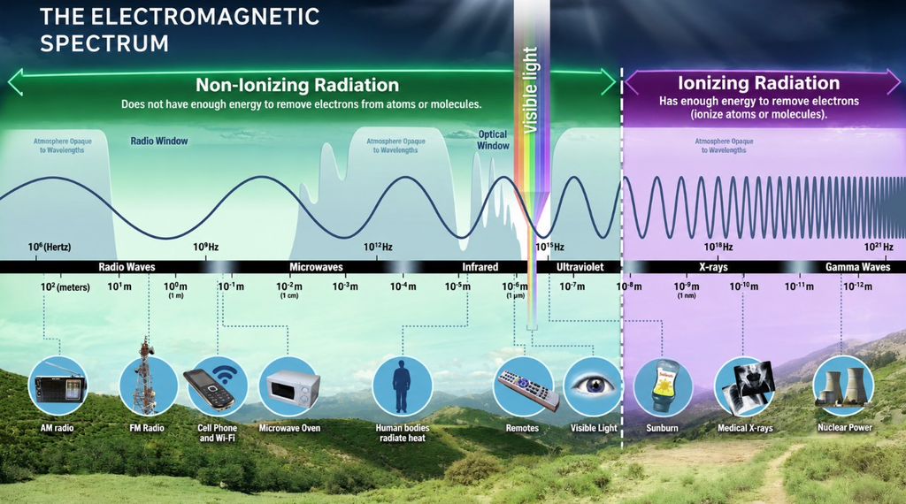

Figure 39: Electromagnetic spectrum illustrating the relationship between wavelength, frequency, and different types of electromagnetic radiation.

*Source: NASA, [Introduction to the Electromagnetic Spectrum](https://science.nasa.gov/ems/01_intro/).*

**Note:** The boundary between ionizing and non-ionizing radiation is not absolute. Although ultraviolet (UV) radiation is commonly classified as non-ionizing, sufficiently high-energy UV photons can cause ionization. Furthermore, non-ionizing UV radiation can damage DNA through photochemical reactions without directly ionizing atoms or molecules.

#### X-Ray Radiation and X-Ray Tubes

**X-ray radiation** is a form of electromagnetic radiation with sufficient photon energy to ionize atoms and molecules.

Like gamma ($\gamma$) rays, X-rays have no electric charge or rest mass and can penetrate matter. However, **X-rays and gamma rays are commonly distinguished by how they are produced**.

Gamma rays are generally emitted during nuclear transitions, whereas X-rays can be produced when high-speed electrons interact with matter or when electrons transition between atomic energy levels.

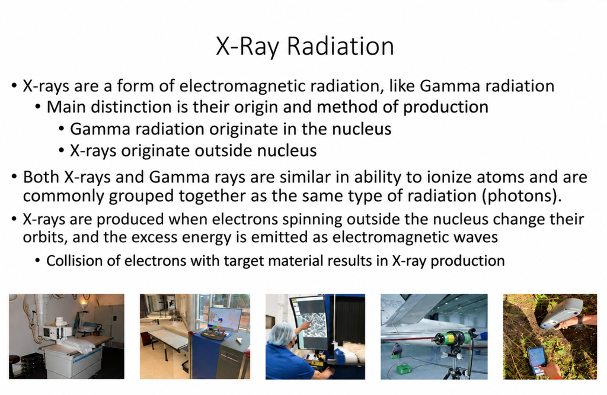

Figure 40: X-ray radiation illustration from NASA Armstrong Flight Research Center radiation safety training.

*Source: NASA Armstrong Flight Research Center (AFRC), Radiation Safety Training.*

##### The Discovery of X-Rays

On November 8, 1895, **Wilhelm Conrad Röntgen**, a German physicist, discovered X-rays while experimenting with electrical discharge tubes. He observed that invisible radiation could penetrate certain materials and produce images on photographic plates.

The development of controllable X-ray sources helped establish the field of **radiography**, which uses penetrating radiation to produce images of objects and internal structures.

[figure not shown]

Figure 41: Wilhelm Conrad Röntgen (1845–1923), the German physicist who discovered X-rays in 1895, alongside the famous early X-ray image of his wife Anna Bertha Ludwig’s hand. Source: [Wikipedia](https://en.wikipedia.org/wiki/Wilhelm_R%C3%B6ntgen).

[figure not shown]

Figure 42: Historical illustration of Wilhelm Conrad Röntgen experimenting with an electrical discharge tube to investigate X-rays. Source: [Alamy](https://www.alamy.com/stock-photo-wilhelm-conrad-roentgen-1845-1923-german-experimental-physicist-and-104020180.html).

##### How Are X-Rays Produced?

An **X-ray tube** is a vacuum tube that converts electrical energy into X-ray radiation.

An X-ray tube contains two principal electrodes:

- **Cathode (negative electrode):** Contains a heated filament that releases electrons through a process called thermionic emission.
- **Anode (positive electrode):** Contains a metal target, commonly tungsten, toward which electrons are accelerated by a high voltage.

When the electrons strike the anode target, they rapidly lose energy. A portion of this energy is emitted as **X-ray photons**, while most is converted into heat.

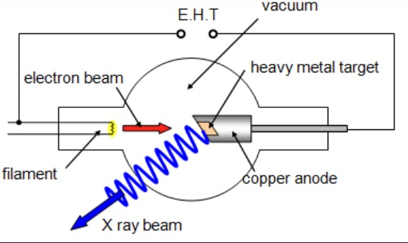

Figure 43: Diagram illustrating the production of X-rays inside an X-ray tube.

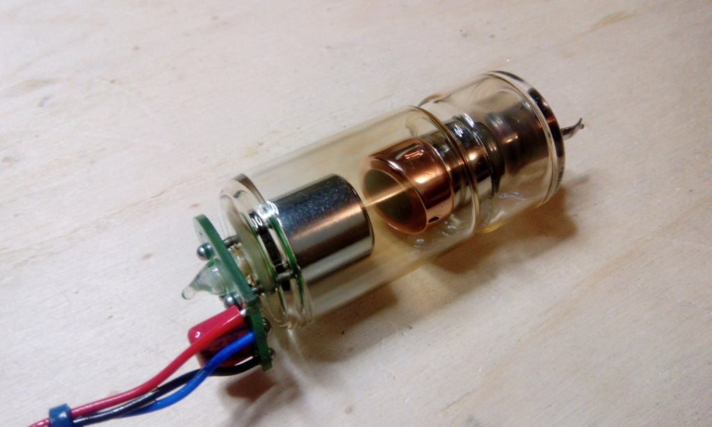

Figure 44: Example of an X-ray tube used to generate X-ray radiation.

*Source: [PhysicsOpenLab, X-Ray Tube Diagram](https://physicsopenlab.org/wp-content/uploads/2017/10/xraytube_scheme.png).*

##### Applications and Radiation Safety

X-ray tubes are used in medical radiography, computed tomography (CT), airport luggage scanners, X-ray crystallography, material analysis, and industrial inspection.

An important distinction between an electrically powered X-ray tube and a radioactive source is that **an X-ray tube produces X-rays only while it is energized and operating**.

When electrical power is removed, X-ray production stops. This does not mean that the equipment is free of other hazards, such as stored electrical energy.

In hazardous materials management, understanding how radiation is produced helps us distinguish between **radiation-generating equipment** and **radioactive materials**.

### Ionizing Radiation Exposure Sources

We have examined how ionizing radiation is produced and how it interacts with matter. But where does our exposure to ionizing radiation come from?

Humans are continuously exposed to ionizing radiation from both **natural background sources** and **human-made sources**.

#### Annual Radiation Exposure

The following figure illustrates the estimated contributions of natural background radiation and human-made sources to annual radiation exposure in the United States.

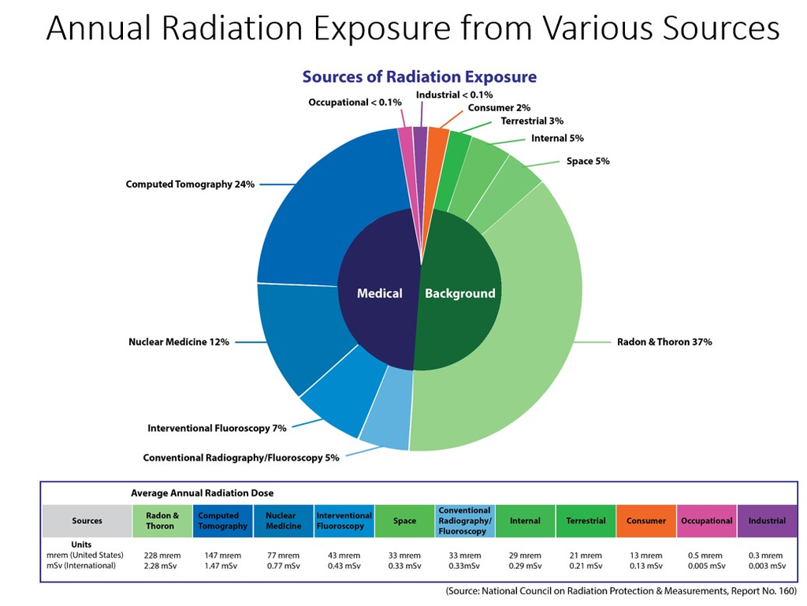

Figure 45: EPA chart showing the estimated sources of average annual radiation exposure in the United States.

According to the [U.S. Environmental Protection Agency (EPA)](https://www.epa.gov/radiation/radiation-sources-and-doses#averagedoses), citing the National Council on Radiation Protection and Measurements (NCRP), Report No. 160, the estimated **average annual effective dose from ionizing radiation in the United States is 6.2 millisieverts (mSv), or 620 millirem (mrem), per person**.

The figure highlights several important sources of radiation exposure:

- **Natural background radiation (approximately 3.1 mSv/year):** Includes radon and thoron, cosmic radiation, terrestrial radiation, and naturally occurring radionuclides that enter the body through food, drinking water, and inhalation.
- **Medical radiation (approximately 3.0 mSv/year):** Includes diagnostic imaging, particularly computed tomography (CT), and nuclear medicine procedures.
- **Other human-made sources:** Include consumer products, occupational activities, and industrial applications, which contribute comparatively little to the population average.

Notice that **radon and thoron are major contributors to natural background radiation exposure**, while medical procedures account for much of the human-made contribution.

**Note:** These values represent historical U.S. population averages based primarily on 2006 exposure data, as reported in NCRP Report No. 160 (2009). Individual radiation doses vary depending on geographic location, medical procedures, occupation, and other exposure conditions.

*Source: [U.S. Environmental Protection Agency (EPA), Radiation Sources and Doses: Average U.S. Doses and Sources](https://www.epa.gov/radiation/radiation-sources-and-doses#averagedoses). Data attributed to NCRP Report No. 160 (2009).*

##### Natural Background Sources of Ionizing Radiation in the United States

According to NCRP Report No. 160, the historical average annual effective dose from natural background radiation in the United States is approximately **3.11 mSv/year (311 mrem/year)**.

The major contributors include:

- **Radon and thoron (2.28 mSv/year):** Naturally occurring radioactive gases and their decay products, which contribute to internal radiation exposure primarily through inhalation.
- **Cosmic radiation (0.33 mSv/year):** Radiation originating from space. Exposure varies with altitude and geographic location.
- **Internal radionuclides (0.29 mSv/year):** Naturally occurring radioactive isotopes, including potassium-40 (${}^{40}_{19}\mathrm{K}$) and polonium-210 (${}^{210}_{84}\mathrm{Po}$), that enter the body through food, drinking water, and other environmental exposure pathways.
- **Terrestrial radiation (0.21 mSv/year):** Radiation emitted by naturally occurring radioactive materials in soil, rocks, and building materials.

Of these sources, **radon and thoron account for the largest contribution to natural background radiation exposure**.

*Source: National Council on Radiation Protection and Measurements (NCRP), Report No. 160 (2009), as summarized by the [U.S. Environmental Protection Agency (EPA)](https://www.epa.gov/radiation/radiation-sources-and-doses#averagedoses).*

###### How Is Radon Gas Formed?

Radon is a naturally occurring radioactive noble gas produced through the decay of radioactive elements found in rocks and soils.

In the uranium-238 decay series, uranium undergoes several radioactive transformations before producing radium-226. Radium-226 then undergoes alpha decay to produce radon-222:

$${}^{226}_{88}\mathrm{Ra}
\rightarrow
{}^{222}_{86}\mathrm{Rn}
+
{}^{4}_{2}\mathrm{He}$$

Where:

- **Radium-226 (**${}^{226}_{88}\mathrm{Ra}$): The radioactive parent nuclide.
- **Radon-222 (**${}^{222}_{86}\mathrm{Rn}$): The radioactive daughter nuclide produced by alpha decay.
- **Alpha particle (**${}^{4}_{2}\mathrm{He}$): A helium nucleus consisting of two protons and two neutrons.

Because radon is a gas, it can escape from mineral grains and migrate through pores, fractures, and other openings in surrounding soil and rock.

Some radon reaches the outdoor atmosphere, while some enters groundwater or migrates toward buildings.

*Sources: [U.S. Geological Survey (USGS), What Is Radon?](https://www.usgs.gov/faqs/what-radon); [U.S. Environmental Protection Agency (EPA), How Does Radon Get Into Your Home?](https://www.epa.gov/radon/how-does-radon-get-your-home).*

###### Why Do Radon Concentrations Vary Across the United States?

Although radon is produced naturally, its concentration is not uniform across the United States.

The amount of radon produced and its movement through the environment depend on several factors:

- **Geology:** The concentrations of uranium and radium in local rocks and soils influence the amount of radon that can be produced.
- **Soil permeability:** The ability of soil and rock to transmit gases influences how readily radon can migrate toward the surface.
- **Glacial deposits:** In some regions, glacially transported sediments contain uranium- and radium-bearing minerals that contribute to local radon potential.
- **Building characteristics:** Foundations, basements, crawl spaces, and openings around pipes can provide pathways for radon to enter indoor spaces.
- **Ventilation and pressure differences:** Air movement and pressure differences between buildings and the surrounding soil influence how much radon enters and accumulates indoors.

The following map illustrates generalized geologic radon potential across the United States.

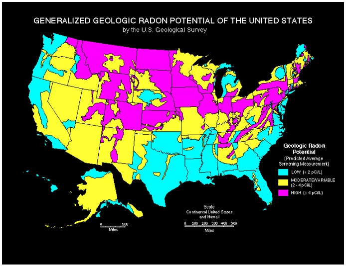

Figure 46: Generalized geologic radon potential across the United States, showing regions of low, moderate, and high predicted indoor radon concentrations.

*Source: U.S. Geological Survey (USGS), Generalized Geologic Radon Potential of the United States. Based on USGS Open-File Report 93-292 (1993). Map reproduced in [U.S. EPA, Pennsylvania Radon Program: An Update (2022)](https://www.epa.gov/system/files/documents/2022-08/An-Update-PA-Radon-Program.pdf).*

The researchers identified elevated predicted indoor radon concentrations in portions of the **Midwest and northern Great Plains**, including parts of North Dakota, South Dakota, Iowa, and Nebraska.

However, **a regional map cannot determine the radon concentration inside an individual building**. Indoor concentrations also depend on local geology, building construction, ventilation, and other factors.

###### How Does Radon Enter Buildings?

The geographic distribution of radon helps us understand where elevated concentrations may occur, but it does not explain how radon reaches people.

To understand the potential for exposure, we must consider how radon moves from its source in the environment into indoor spaces.

The following illustration from the Centers for Disease Control and Prevention (CDC) shows how radon can enter buildings from the surrounding soil and through groundwater.

[figure not shown]

Figure 47: Illustration showing pathways through which radon can enter a home from surrounding soil and groundwater.

Radon can enter homes and other buildings through cracks and openings in foundations, floors, walls, and around plumbing penetrations.

Radon can also dissolve in groundwater and enter buildings through the household water supply, particularly when water comes from underground sources such as private wells.

According to the [Connecticut Department of Public Health](https://portal.ct.gov/dph/environmental-health/radon/radon-in-water?language=en_US), radon dissolved in water can be released into indoor air when water is heated or agitated during activities such as showering, washing clothes, or cooking.

Once indoors, radon may accumulate depending on building ventilation, air pressure differences, and other environmental conditions.

*Sources: Centers for Disease Control and Prevention (CDC), [Radon in the Home](https://www.cdc.gov/radon/about/radon-home.html); Connecticut Department of Public Health, [Radon in Water](https://portal.ct.gov/dph/environmental-health/radon/radon-in-water?language=en_US).*

The presence of naturally occurring radioactive materials in the environment does not automatically determine an individual’s radiation exposure. We must also consider **how radioactive substances move through the environment, how they enter buildings, and whether an exposure pathway exists**.

These pathways are particularly important for understanding radon as an indoor air quality hazard.

#### Average Background Radiation and Common Exposure Sources

Not everyone receives the same amount of radiation exposure.

Background radiation can vary with **altitude, latitude, geology, and the presence of naturally occurring radioactive materials**.

For example, people living at higher elevations may receive greater exposure to cosmic radiation because there is less atmosphere above them to attenuate incoming radiation.

Similarly, exposure to radon can vary considerably depending on local geology and building conditions.

[figure not shown]

Figure 48: University of Washington radiation safety training slide comparing background radiation and common exposure scenarios.

*Source: University of Washington, Environmental Health & Safety, Background Radiation Anchoring, November 12, 2026.*

The figure provides examples to help us put radiation exposure into perspective. However, it is important to distinguish between **annual exposure**, **dose from a single procedure**, and **regulatory dose limits**.

##### Radioactive Materials in Cigarette Smoke

Another example of radiation exposure comes from cigarette smoking.

Tobacco plants can accumulate naturally occurring radioactive materials, particularly **lead-210 (**${}^{210}_{82}\mathrm{Pb}$) and **polonium-210 (**${}^{210}_{84}\mathrm{Po}$).

These radionuclides originate from naturally occurring radioactive decay processes involving uranium, radium, and radon in the environment.

According to the [U.S. Environmental Protection Agency (EPA)](https://www.epa.gov/radtown/radioactivity-tobacco), radioactive materials can enter tobacco plants through their roots or become deposited on the surfaces of their leaves. Some radioactive decay products remain attached to tobacco leaves even after processing.

When a person smokes a cigarette, radioactive particles can be inhaled and deposited within the respiratory tract.

This is particularly important for **polonium-210**, which undergoes alpha decay:

$${}^{210}_{84}\mathrm{Po}
\rightarrow
{}^{206}_{82}\mathrm{Pb}
+
{}^{4}_{2}\mathrm{He}$$

Where:

- **Polonium-210 (**${}^{210}_{84}\mathrm{Po}$): The radioactive parent nuclide.
- **Lead-206 (**${}^{206}_{82}\mathrm{Pb}$): The stable daughter nuclide.
- **Alpha particle (**${}^{4}_{2}\mathrm{He}$): A helium nucleus consisting of two protons and two neutrons.

Although alpha particles have limited penetration through intact skin, they can deposit energy in nearby biological tissues when emitted by radioactive material inside the body.

The [Centers for Disease Control and Prevention (CDC)](https://www.cdc.gov/radiation-health/data-research/facts-stats/cigarette-smoking.html) explains that lead-210 and polonium-210 can accumulate in the lungs of people who smoke, contributing to radiation exposure and lung cancer risk.

**Important distinction:** The principal causes of smoking-related cancer include the many chemical carcinogens present in tobacco smoke. Radioactive materials represent an additional potential contributor to radiation-induced cellular damage.

This example illustrates an important concept in hazardous materials chemistry: **the biological hazard associated with radioactive material depends not only on the type of radiation emitted, but also on where the radioactive material is located relative to the body**.

To understand this distinction, we must differentiate between radiation reaching the body from an external source and radioactive material entering the body through inhalation, ingestion, or other exposure pathways.

*Sources: [U.S. Environmental Protection Agency (EPA), Radioactivity in Tobacco](https://www.epa.gov/radtown/radioactivity-tobacco); [Centers for Disease Control and Prevention (CDC), Facts About Cigarette Smoking and Radiation](https://www.cdc.gov/radiation-health/data-research/facts-stats/cigarette-smoking.html).*

##### Comparing Radiation Doses from Different Sources

We have examined several sources of ionizing radiation, including natural background radiation, medical procedures, and radon.

However, **not all radiation exposures deliver the same dose**, and the presence of radioactive material does not necessarily mean that a person receives a high radiation dose.

The following figure compares radiation doses associated with different sources and activities. Notice how the relative magnitudes differ depending on the source and exposure conditions.

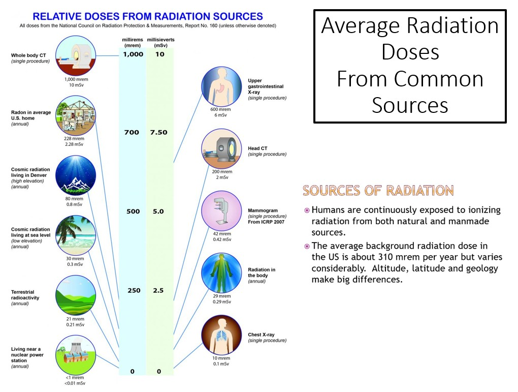

Figure 49: Comparison of average radiation doses from common natural and medical sources.

*Source: National Council on Radiation Protection and Measurements (NCRP), Report No. 160, as attributed in the figure.*

The figure uses two units commonly encountered in radiation protection:

- **Millirem (mrem):** One-thousandth of a rem, a traditional unit used for radiation protection dose quantities.
- **Millisievert (mSv):** One-thousandth of a sievert, the corresponding SI unit for equivalent or effective dose.

For these radiation protection dose quantities:

$$1\ \mathrm{mSv}=100\ \mathrm{mrem}$$

When interpreting the figure, remember that **annual background radiation, a single medical procedure, and occupational dose limits describe different exposure scenarios**. Their numerical values should not be interpreted as directly equivalent situations.

#### Types of Radiation Exposure: External vs. Internal

Radiation can reach the body from a source outside it, or radioactive material can enter the body. These situations require different exposure assessments and protective measures.

[figure not shown]

Figure 50: University of Washington illustration comparing external radiation exposure and internal radiation exposure.

Two important distinctions are:

- **External irradiation:** Radiation emitted by a source outside the body reaches a person. This does not necessarily leave radioactive material on or inside the person.
- **Internal contamination:** Radioactive material enters the body through inhalation, ingestion, a wound, or injection and can irradiate tissues from within.

An alpha emitter may present a relatively limited external radiation hazard because alpha particles have low penetrating ability. However, the same radioactive material may present a significant hazard if inhaled or ingested.

In contrast, penetrating gamma radiation can expose internal tissues even when the radioactive source remains outside the body.

**Important distinction:** A person can be exposed to radiation without becoming contaminated with radioactive material.

For hazardous materials responders, determining whether the primary concern is external irradiation, radioactive contamination, or both helps guide exposure assessments and protective measures.

*Source: University of Washington, Environmental Health & Safety, Ionizing Radiation Safety – Internal Radiation, Philip Campbell, CHP, Spring 2022.*

### Internal Contamination and Biological Distribution

What happens when radioactive material enters the body?

Unlike an external radiation source, radioactive material taken into the body may remain present and continue irradiating surrounding tissues.

Its **chemical behavior** affects where it travels, how it interacts with biological systems, and which tissues may receive a radiation dose.

Radioactive material may circulate through the bloodstream, accumulate in particular organs, or be eliminated through biological processes.

[figure not shown]

Figure 51: Radiological contamination and its relationship to radiation exposure.

#### Exposure Pathways and Movement Through the Body

There are several pathways through which radioactive material may enter the body:

- **Ingestion:** Radioactive material enters through the gastrointestinal tract, where some may be absorbed into the bloodstream.
- **Inhalation:** Airborne radioactive particles or gases enter the respiratory tract. Depending on their properties, they may be retained, cleared, swallowed, or absorbed into the bloodstream.
- **Injection or wounds:** Radioactive material may enter through punctures, contaminated wounds, or other breaches in the skin.
- **Absorption:** Certain radioactive substances may enter through the skin, depending on their chemical and physical properties.

Once radioactive material enters the body, it may move through several biological compartments.

For example, inhaled radioactive material may initially deposit in the respiratory tract. Some material may remain in the lungs, while other material may enter systemic circulation or be transported to the gastrointestinal tract.

Material entering the bloodstream may subsequently reach other organs and tissues.

The body may also eliminate radioactive material through urine, feces, or other biological processes.

[figure not shown]

Figure 52: Occupational radiation exposure pathways and the movement of radioactive material through the body.

**Chemical connection:** Radioactive isotopes of an element generally participate in the same chemical processes as their stable counterparts. Consequently, understanding the chemical behavior of an element can help predict where its radioactive isotopes may travel or accumulate in the body.

##### Example: Radioactive Iodine, the Thyroid Gland, and Chernobyl

To understand why the chemical properties of radioactive material matter, consider the thyroid gland.

The **thyroid** is a small, butterfly-shaped gland located in the front of the neck. Its primary function is to produce hormones that help regulate the body’s metabolism.

[figure not shown]

Figure 53: Anatomy of the thyroid gland, showing its location in the neck and its two lobes connected by the isthmus.

*Image source: [Cleveland Clinic, Thyroid: What It Is, Function & Problems](https://my.clevelandclinic.org/health/body/23188-thyroid).*

To produce these hormones, the thyroid requires **iodine**, an essential element obtained through the diet from sources such as iodized salt, dairy products, and seafood.

After iodine is absorbed into the bloodstream, the thyroid takes up some of it and uses it to produce thyroid hormones.

However, the thyroid cannot distinguish between stable iodine and radioactive isotopes of iodine.

This creates a potential radiation hazard.

**Iodine-131 (**$^{131}\mathrm{I}$) is a radioactive isotope produced during nuclear fission. It emits beta particles and gamma radiation and has a physical half-life of approximately 8 days.

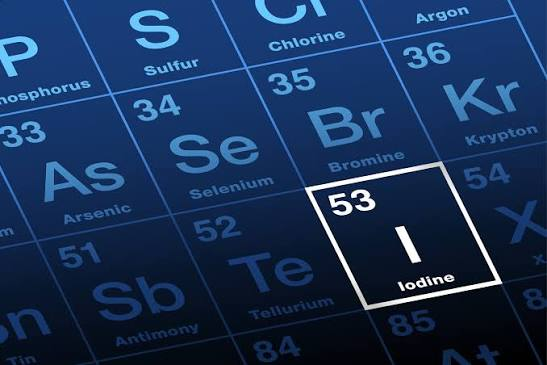

Figure 54: Iodine, the chemical element essential for thyroid hormone production, including its radioactive isotope iodine-131.

*Image source: [Centers for Disease Control and Prevention (CDC), Iodine-131, Radiation Emergencies](https://www.cdc.gov/radiation-emergencies/hcp/isotopes/iodine-131.html), updated January 31, 2025.*

If iodine-131 enters the body through contaminated food, water, or air, some of it may be absorbed into the bloodstream and subsequently concentrated in the thyroid gland.

As the iodine-131 undergoes radioactive decay, it can deliver radiation dose to thyroid tissue.

The amount of radiation dose received depends on how much radioactive iodine enters the body, how much accumulates in the thyroid, and how long it remains there.

This provides an important example of how **the chemical behavior of an element influences where radioactive material accumulates and which organs may be exposed**.

###### Historical Example: The Chernobyl Nuclear Accident (1986)

On April 26, 1986, a reactor accident at the Chernobyl Nuclear Power Plant in present-day Ukraine released radioactive materials into the environment, including iodine-131.

Radioactive iodine entered the environment through atmospheric releases and contaminated vegetation and food supplies.

One important exposure pathway involved dairy products.

Radioactive iodine deposited on pasture grass could be consumed by grazing cows and transferred into their milk.

People who drank contaminated milk could then ingest iodine-131, which could subsequently accumulate in their thyroid glands.

This pathway was particularly important for children, whose thyroid glands are more sensitive to radiation-related cancer risks.

Following the Chernobyl accident, a substantial increase in thyroid cancer was observed among people exposed as children or adolescents in affected regions.

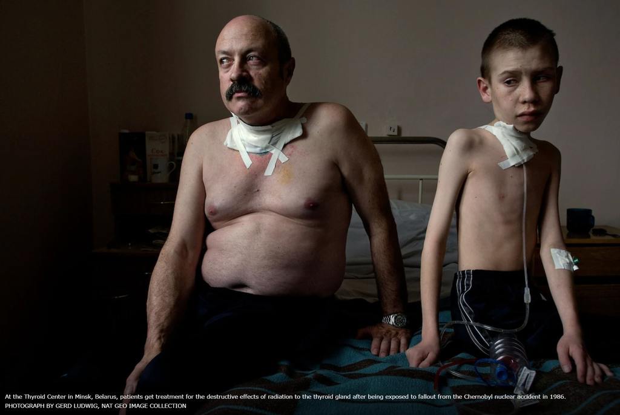

Figure 55: Thyroid cancer and the health consequences of radioactive iodine exposure following the 1986 Chernobyl nuclear accident.

*Image source: [Medizzy Journal, Study Assesses Link Between Thyroid Cancer and Chernobyl Fallout](https://journal.medizzy.com/study-assesses-link-between-thyroid-cancer-and-chernobyl-fallout/).*

**Chemical connection:** The thyroid’s normal biological function requires iodine. Unfortunately, that same biological process can concentrate radioactive iodine in thyroid tissue following internal contamination.

The Chernobyl example illustrates how environmental contamination can move through the food chain and result in radiation exposure to a particular organ.

*Sources: Centers for Disease Control and Prevention (CDC), [Iodine-131](https://www.cdc.gov/radiation-emergencies/hcp/isotopes/iodine-131.html), updated January 31, 2025; Cember, H., & Johnson, T. E., Introduction to Health Physics (4th ed.), discussion of the thyroid gland and iodine metabolism.*

###### Why Is Iodine Added to Table Salt?

You may be wondering whether iodine is added to table salt in the United States to protect people from radioactive fallout.

**The answer is no.**

Iodine is added to table salt primarily to prevent dietary iodine deficiency and associated health conditions, including goiter.

Although the thyroid requires iodine for normal function, consuming iodized table salt does not provide effective protection against radioactive iodine exposure during a nuclear or radiological emergency.

Instead, public health officials may recommend **potassium iodide (KI)** in certain emergencies involving radioactive iodine.

Potassium iodide contains stable, non-radioactive iodine.

When taken at the appropriate time and in the appropriate amount, KI can saturate the thyroid with stable iodine, reducing its uptake of radioactive iodine.

However, several important limitations apply:

- **KI protects only the thyroid gland** and does not protect other organs from radiation exposure.
- **KI protects against radioactive iodine**, not against other radioactive materials or external radiation.
- **Timing matters:** KI is most effective when taken shortly before or soon after exposure to radioactive iodine.
- **Iodized salt is not a substitute for KI.** Consuming large amounts of salt to obtain iodine can be dangerous.
- **KI should only be taken when instructed by public health officials, emergency responders, or healthcare providers.**

This distinction reinforces an important principle of radiation protection: **protective measures must be selected according to the specific radioactive material and exposure pathway involved**.

*Source: Centers for Disease Control and Prevention (CDC), [Potassium Iodide (KI)](https://www.cdc.gov/radiation-emergencies/treatment/potassium-iodide.html), updated January 30, 2025.*

*Additional source: University of Washington, Environmental Health & Safety, Ionizing Radiation Safety – Internal Radiation, Philip Campbell, CHP, Spring 2022. See also UW radiation safety training, “Worker Exposure Pathways,” p. 17.*

#### What Determines the Radiation Dose to an Organ?

The location of radioactive material inside the body is important because different tissues may receive different radiation doses.

[figure not shown]

Figure 56: Anatomical illustration of human internal organs and their locations within the body.

*Image source: [Netter Images, Elsevier, Human Anatomy Illustration](https://www.netterimages.com/chapters.htm?book_id=160&id=23817&page=274).*

When evaluating internal contamination, radiation protection professionals consider several questions:

- **Radionuclide identity:** Which radioactive isotope entered the body?
- **Amount taken in:** How much radioactive material was inhaled, ingested, or otherwise introduced?
- **Particle size:** If radioactive material was inhaled, how large were the airborne particles, and where might they deposit in the respiratory tract?
- **Biological distribution:** Which organs or tissues retain the radioactive material, and how much activity reaches each?
- **Radiation type and energy:** Does the material emit alpha particles, beta particles, gamma rays, or other radiation?
- **Exposure duration:** Was the intake a single event, or did exposure continue over an extended period?
- **Physical decay:** How quickly does the radionuclide undergo radioactive decay?
- **Biological elimination:** How quickly does the body remove the material?

These factors help explain why the **activity of a radioactive substance alone does not determine the radiation dose received by a person**.

For example, an alpha-emitting radionuclide deposited inside sensitive tissue can deliver energy over a very short distance, potentially damaging nearby cells.

Furthermore, radioactive material retained in one organ may emit penetrating radiation that deposits energy in another organ.

This introduces an important distinction between a **source organ**, where radioactive material is located, and a **target organ**, where radiation energy is deposited.

The source and target organs are not necessarily the same.

[figure not shown]

Figure 57: Source and target organs in internal radiation dosimetry, illustrating how radioactive material located in one organ may deliver radiation dose to another organ.

*Image source: [Research article available through PubMed Central (PMC11440950)](https://pmc.ncbi.nlm.nih.gov/articles/PMC11440950/).*

*Additional source: University of Washington, Environmental Health & Safety, radiation safety training, “Dose to an Organ” and “Doses to Other Organs,” pp. 18 and 21.*

#### Physical, Biological, and Effective Half-Life

When radioactive material enters the body, its activity may decrease through two processes: **radioactive decay** and **biological elimination**.

These processes are described using three related concepts:

- **Physical Half-Life (**$T_{\mathrm{phys}}$): The time required for half of the radioactive nuclei of an isotope to undergo spontaneous nuclear decay. The physical half-life is a characteristic property of each radionuclide and is not meaningfully affected by ordinary changes in temperature, chemical form, or biological environment.
- **Biological Half-Life (**$T_{\mathrm{biol}}$): The time required for the body’s biological processes, including metabolism and excretion, to eliminate half of a substance from the body or a particular organ or compartment, without considering radioactive decay. Elimination may occur through urine, feces, perspiration, respiration, or other biological pathways.
- **Effective Half-Life (**$T_{\mathrm{eff}}$): The time required for the radioactive activity retained in the body or a particular organ to decrease by half through the combined effects of radioactive decay and biological elimination.

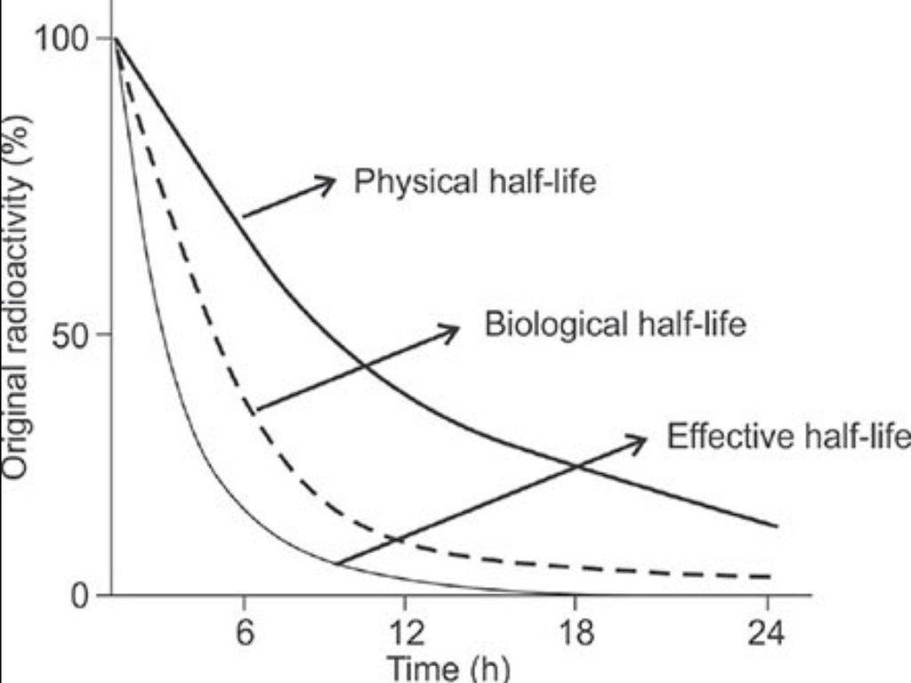

Figure 58: Physical, biological, and effective half-life of radioactive material within the body.

*Image source: Thayalan K. [The Physics of Radiology and Imaging](https://www.jaypeedigital.com/book/9789351521716), Chapter 12, “Gamma Imaging.” Jaypee Brothers Medical Publishers. DOI: 10.5005/jp/books/12361_12.*

Because radioactive decay and biological elimination can occur simultaneously, the **effective half-life is shorter than either the physical or biological half-life**, provided both processes follow exponential behavior with finite, positive half-lives.

For example, a radioactive substance may undergo nuclear decay while the body simultaneously removes some of that substance through urine or other biological processes.

**The important distinction is that physical half-life describes a nuclear property, biological half-life describes how the body processes and eliminates a substance, and effective half-life describes the combined reduction in retained radioactivity.**

Actual biological distribution and elimination may involve multiple organs or compartments and require more complex models.

*Additional sources: [U.S. Nuclear Regulatory Commission, Effective Half-Life](https://www.nrc.gov/education-regulatory-research/glossary/half-life-effective); [HyperPhysics, Biological and Effective Half-Life](http://hyperphysics.phy-astr.gsu.edu/hbase/Nuclear/biohalf.html).*

##### Activity Retained in an Organ Over Time

Activity of radioactive material in an organ can change following an intake.

Immediately following an intake, the activity measured in an organ may increase as radioactive material is transported to and taken up by that tissue.

After reaching a maximum, the activity may begin to decrease as radioactive decay and biological elimination occur.

[figure not shown]

Figure 59: Activity of radioactive material retained in an organ or tissue over time following an intake.

*Image source: University of Washington, Environmental Health & Safety, Ionizing Radiation Safety Training, “Activity in an Organ/Tissue,” p. 19.*

The amount of activity present in the organ therefore changes over time.

Importantly, the radiation dose delivered to an organ depends not only on the activity present at one moment, but also on **how much radioactive activity is retained over time**.

A radionuclide that remains in an organ for an extended period may continue irradiating nearby tissue even after the original exposure event has ended.

**Conceptual connection:** Physical half-life and biological elimination help explain how long radioactive material may continue contributing to internal radiation exposure.

*Source: University of Washington, Environmental Health & Safety, radiation safety training, “Activity in an Organ/Tissue” and “Effective Decay Constant,” pp. 19–20.*

### Biological Effects of Ionizing Radiation

We have examined how radioactive materials can enter the body, accumulate in different organs, and continue emitting radiation over time.

But what happens when ionizing radiation interacts with living tissue?

Ionizing radiation can transfer energy to atoms and molecules within cells, potentially damaging important biological structures, including DNA.

Cells may successfully repair this damage, die as a result of the injury, or survive with changes that affect their normal function.

**Not every radiation exposure results in observable biological injury.** The consequences depend on several factors, including the amount of radiation received, how quickly the radiation dose is delivered, the type of radiation, and which tissues are exposed.

Radiation protection professionals distinguish between two broad categories of biological effects:

- **Tissue Reactions (Deterministic or Non-Stochastic Effects):** These are health effects that generally occur when a sufficiently high radiation dose is delivered to a particular tissue or organ. A **threshold dose** is believed to exist, meaning that the effect is not expected to occur below a certain radiation dose. Once that threshold is exceeded, the **severity of the injury generally increases as the radiation dose increases**. Examples include skin reddening (erythema), hair loss (epilation), cataracts, impaired reproductive function, and acute radiation syndrome (ARS).
- **Stochastic Effects:** These are health effects that occur by chance. In radiation protection, the primary concern is **radiation-induced cancer**. Unlike tissue reactions, radiation protection models generally assume that there is no threshold dose below which the risk is completely absent. Instead, the **probability of developing cancer increases with radiation dose**, while the severity of the cancer does not depend on the radiation dose that initially contributed to its development.

#### Historical Evidence: Survivors of Hiroshima and Nagasaki

One important source of scientific evidence about the long-term health effects of ionizing radiation comes from studies of survivors of the atomic bombings of Hiroshima and Nagasaki in August 1945.

Researchers have followed populations of atomic-bomb survivors over many decades to investigate relationships between radiation exposure and subsequent cancer development.

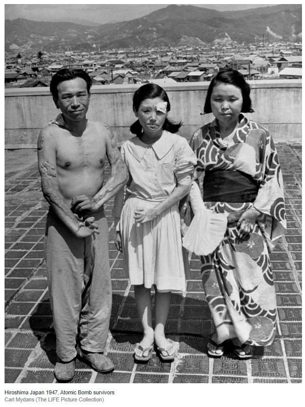

Figure 60: Historical photographs of survivors of the atomic bombing of Hiroshima, Japan, in August 1945.

*Image source: [LIFE Magazine, Hiroshima: Portraits of Survivors](https://www.life.com/history/hiroshima-portraits-of-survivors/).*

The following table presents cancer incidence data from a population of **86,572 atomic-bomb survivors with known radiation doses**.

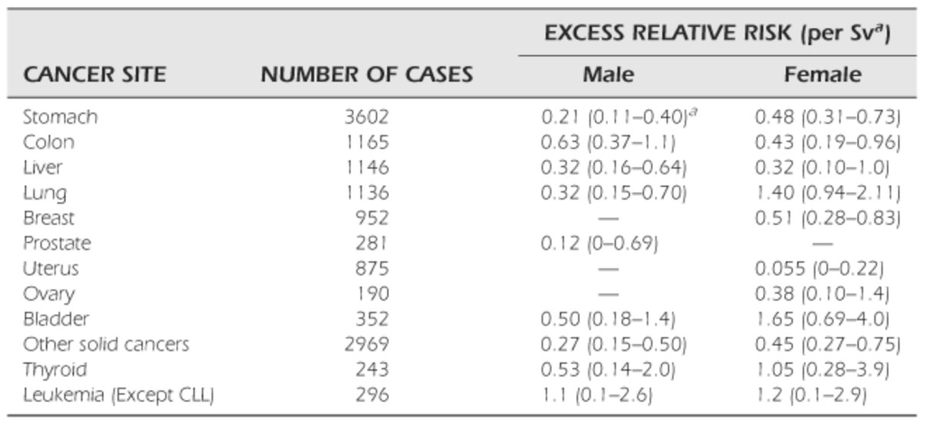

Figure 61: Cancer incidence among 86,572 atomic-bomb survivors with known radiation doses, illustrating epidemiological evidence used to evaluate the relationship between ionizing radiation exposure and cancer risk.

*Source: National Research Council, Committee to Assess Health Risks from Exposure to Low Levels of Ionizing Radiation. BEIR VII: Health Risks from Exposure to Low Levels of Ionizing Radiation. Washington, DC: National Academies Press, 2005. Table 7-9. Reproduced with permission from the National Academies Press. Copyright © 2005, National Academy of Sciences.*

Studies of atomic-bomb survivors provide important epidemiological evidence relating radiation dose to cancer risk.

These findings help scientists estimate radiation-related cancer risks and develop radiation protection recommendations.

Understanding these differences helps explain why radiation protection programs seek to prevent tissue injuries while minimizing unnecessary radiation exposure and reducing the risk of radiation-related cancer.

# Part IV. Radiation Dosimetry and Protection

In the previous section, we examined how ionizing radiation interacts with living tissue and how radiation exposure can produce biological effects.

We learned that sufficiently high radiation doses can cause tissue reactions, while the probability of stochastic effects, particularly radiation-induced cancer, generally increases with radiation dose.

These biological effects raise an important question:

**If ionizing radiation can cause biological harm, how do we protect ourselves and others from unnecessary exposure?**

Radiation protection programs address this question through a principle known as **ALARA**.

## ALARA: As Low As Reasonably Achievable

**ALARA (As Low As Reasonably Achievable)** is a fundamental principle of radiation protection that emphasizes minimizing unnecessary radiation exposure.

The goal is to maintain radiation exposures as far below applicable dose limits as reasonably achievable, considering the purpose of the activity, available technology, and practical circumstances.

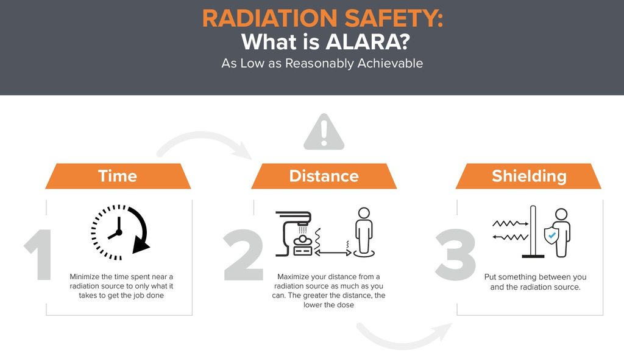

Figure 62: ALARA radiation protection principles.

*Image source: [Landauer, What Does ALARA Mean and Why Is It So Important?](https://www.landauer.com/blog/what-does-alara-mean-and-why-it-so-important)*

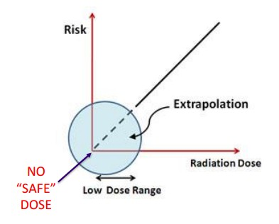

Figure 63: ALARA radiation protection guidance from the University of Washington.

*Source: University of Washington, Environmental Health and Safety, Radiation Safety Office.*

ALARA does not mean that all radiation exposure can be eliminated. Instead, it encourages radiation safety professionals to evaluate potential exposures and implement reasonable measures to reduce them.

Three fundamental methods of controlling external radiation exposure are:

1. **Time:** Reduce the amount of time spent near a radiation source.
2. **Distance:** Increase the distance between yourself and the radiation source.
3. **Shielding:** Place appropriate protective materials between yourself and the radiation source.

These principles are especially important for hazardous materials responders who may encounter radioactive materials or radiation-generating equipment.

When radioactive contamination is possible, additional measures include containment, preventing inhalation or ingestion, controlling access, and conducting appropriate surveys.

However, before we can determine whether radiation protection measures are effective, we must first understand **how radiation is measured**.

### NRC Occupational Dose Limits

The U.S. Nuclear Regulatory Commission establishes occupational and public radiation protection requirements for activities under its jurisdiction in **10 CFR Part 20**. Specific limits and monitoring requirements differ for occupational whole-body dose, individual tissues, declared pregnant workers, and members of the public. NRC rules may be administered by authorized Agreement States for certain activities; other workplaces may fall under different authorities.

[figure not shown]

Figure 64: NRC occupational radiation dose limits presented in radiation safety training.

*Source: NASA Armstrong Flight Research Center, Radiation Safety Office, Ionizing Radiation Safety Training.*

[figure not shown]

Figure 65: Radiation protection requirements concerning declaration of pregnancy and fetal dose limits.

*Source: NASA Armstrong Flight Research Center, Radiation Safety Office, Ionizing Radiation Safety Training.*

**Before using numerical limits for incident decisions, consult the current applicable regulation and radiation safety officer.** [NRC, 10 CFR Part 20](https://www.nrc.gov/reading-rm/doc-collections/cfr/part020/).

### Relevant U.S. Agencies

In the United States, relevant organizations may include:

- **Nuclear Regulatory Commission (NRC):** Regulates certain uses of radioactive materials and nuclear facilities, alongside authorized state programs.
- **Occupational Safety and Health Administration (OSHA):** Enforces applicable workplace safety and health requirements, including ionizing-radiation provisions in covered workplaces.
- **Environmental Protection Agency (EPA):** Establishes certain environmental radiation standards and provides radiological emergency guidance.
- **Food and Drug Administration (FDA):** Regulates medical radiation-emitting electronic products and radiopharmaceuticals within its statutory responsibilities.

## How Do We Measure Ionizing Radiation?

We have learned that unstable atomic nuclei release radiation as they decay and that ionizing radiation can remove electrons from atoms.

But how do scientists measure something they cannot see?

Radiation detection instruments allow us to measure radiation in our surroundings, including workplaces, buildings, and outdoor environments.

Depending on the instrument, we can detect **alpha particles, beta particles, gamma rays, and certain other forms of ionizing radiation**.

Some instruments measure radiation levels in an area, while others help us determine whether radioactive material is present on surfaces, equipment, or in the air.

Before discussing how these instruments work, we need to understand two important measurements: **activity** and **exposure**.

### Activity: Measuring Radioactive Decay

**Activity** tells us how quickly radioactive atoms are decaying.

The unit of activity is the **becquerel (Bq)**, named after Henri Becquerel.

$$1\ \mathrm{Bq}=1\ \mathrm{decay/s}$$

In other words, a radioactive source with an activity of 100 Bq undergoes an average of 100 nuclear transformations every second.

Another unit is the **curie (Ci)**, named in honor of Pierre and Marie Curie.

$$1\ \mathrm{Ci}=3.7\times10^{10}\ \mathrm{Bq}$$

This means that one curie represents 37 billion nuclear transformations per second.

**Important:** Activity tells us how much radioactive decay is occurring, but it does not tell us how much radiation a person is exposed to or absorbs.

*Sources: Cember, H., & Johnson, T. E. Introduction to Health Physics (4th ed.); University of Washington Environmental Health and Safety, Ionizing Radiation Safety: External Radiation (2022); Burdge, J., & Overby, J. Chemistry: Atoms First (2nd ed.), Chapter 20.*

### Exposure in Air

**Exposure (**$X$) describes the electrical charge produced by X-rays or gamma rays through ionization in air, per unit mass of air.

When these forms of radiation pass through air, they can remove electrons from atoms and molecules, producing electrically charged particles.

Scientists can measure this electrical charge to help evaluate radiation exposure.

Two units used to describe exposure are:

- **Coulomb per kilogram (C/kg):** The SI unit of exposure.
- **Roentgen (R):** A traditional unit of exposure, named after Wilhelm Röntgen.

The conversion between these units is:

$$1\ \mathrm{R}=2.58\times10^{-4}\ \mathrm{C/kg}$$

**Important:** Exposure in air is not the same as the radiation dose absorbed by a person’s body.

### Detecting Different Types of Radiation

Different types of radiation interact with matter in different ways. As a result, we need instruments designed for the radiation we want to detect.

Examples of Radiation Detection Methods

| Radiation type | How we can detect it |
| --- | --- |
| Alpha ($\alpha$) | Specialized alpha probes or detectors that measure radiation from radioactive material collected on filters |
| Beta ($\beta$) | Radiation survey probes and Geiger-Müller counters designed to detect beta particles |
| Gamma ($\gamma$) | Ionization chambers, Geiger-Müller counters, and other gamma-sensitive detectors |

**Not every radiation detector can detect every type of radiation.** Selecting the appropriate instrument is an important part of radiation safety.

## Radiation Detection Instruments

Radiation detection instruments allow radiation safety professionals to identify ionizing radiation, evaluate potential exposure hazards, and make informed decisions about worker protection.

Different instruments are designed for different purposes. Some measure radiation exposure or dose rate, while others detect radioactive contamination on surfaces, equipment, or clothing.

### Ionization Chambers

An **ionization chamber** measures the electrical charge produced when radiation ionizes gas inside the detector.

A **coulomb (C)** measures electrical charge. An **ampere (A)** measures current, or charge flowing per second:

$$1\ \mathrm{A}=1\ \mathrm{C/s}$$

When radiation enters an ionization chamber, it can remove electrons from gas molecules, producing positively charged ions and free electrons.

For example, nitrogen gas can be ionized:

$$\mathrm{N_2}+\text{energy}\longrightarrow\mathrm{N_2^+}+\mathrm{e^-}$$

An electric field collects these charged particles, producing a small electrical current that the instrument can measure.

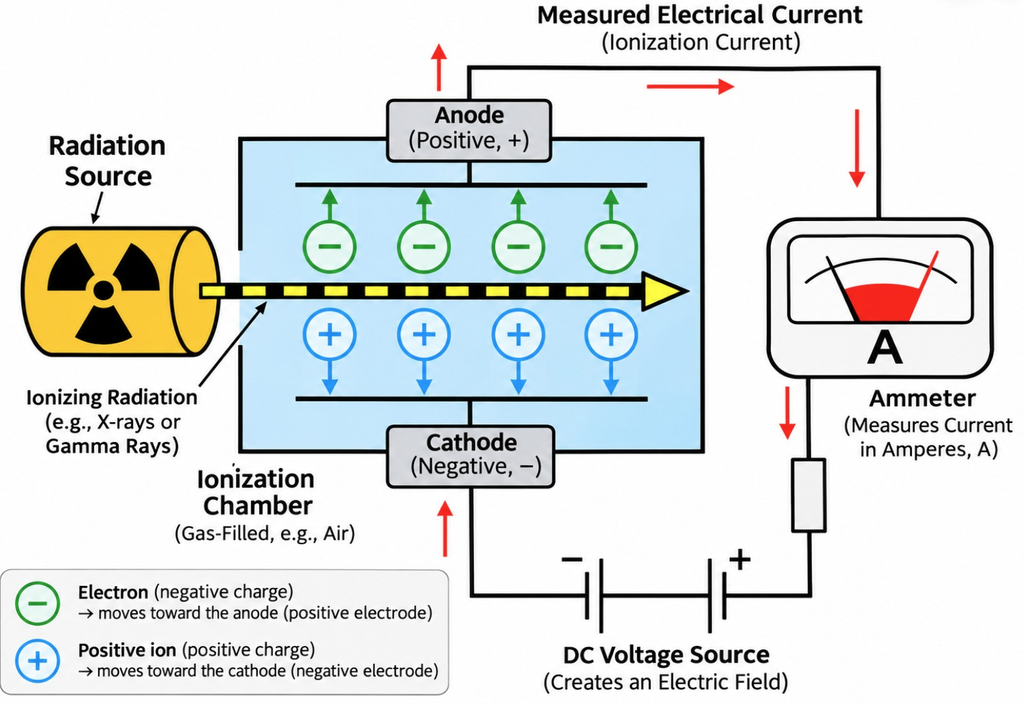

Figure 66: Schematic of an ionization chamber showing how ionizing radiation produces charged particles in a gas-filled chamber. Negatively charged electrons move toward the positive anode, while positively charged ions move toward the negative cathode. The resulting electrical current is measured by an ammeter.

*Figure: Principle of operation of an ionization chamber. Adapted from [Aubase, Ionization Chamber Principle](https://aubase.com/ionization-chamber-principle/).*

Properly calibrated ionization chambers can be used to evaluate radiation exposure rates or dose rates.

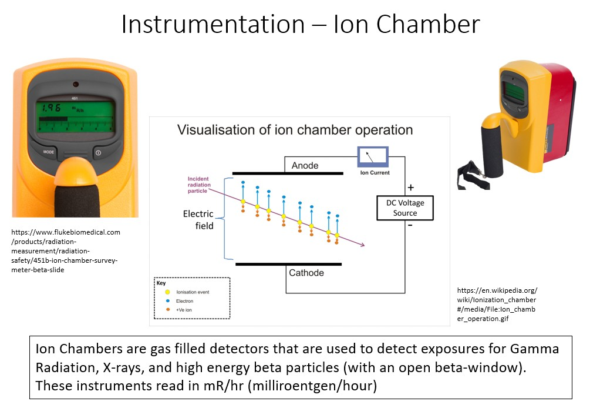

Figure 67: Ionization chamber used for radiation detection and measurement.

*Source: NASA Armstrong Flight Research Center, Ionizing Radiation Safety Training.*

### Radiation Survey Probes

Radiation survey instruments may use different types of **probes**, or detectors, depending on the radiation being measured.

For example, some probes are designed to detect beta particles or gamma rays, while others are designed to identify alpha contamination.

[figure not shown]

Figure 68: Examples of radiation detection probes used in radiation safety surveys.

*Source: NASA Armstrong Flight Research Center, Ionizing Radiation Safety Training.*

Selecting the appropriate probe is important because **not every radiation detector can measure every type of ionizing radiation**.

### How Does a Geiger Counter Work?

A **Geiger-Müller counter**, commonly called a **Geiger counter**, is an instrument used to detect ionizing radiation, including beta particles and gamma rays when the detector is appropriately designed.

The detector contains a gas-filled tube with electrodes connected to a high-voltage electrical supply.

When ionizing radiation enters the tube, it interacts with the gas and produces charged particles.

The process can be summarized in five steps:

1. **Radiation enters the detector.** Ionizing radiation interacts with gas atoms inside the tube.
2. **Ionization occurs.** Electrons are removed from gas atoms, producing positively charged ions and free electrons.
3. **Electrons accelerate.** The electric field attracts electrons toward the positively charged central wire. Accelerating electrons produce additional ionization through collisions with gas atoms.
4. **An electrical pulse forms.** The resulting avalanche of charged particles produces a measurable electrical pulse.
5. **The instrument registers a count.** The electrical pulse is recorded electronically and may be displayed as a numerical count, a meter response, or an audible click.

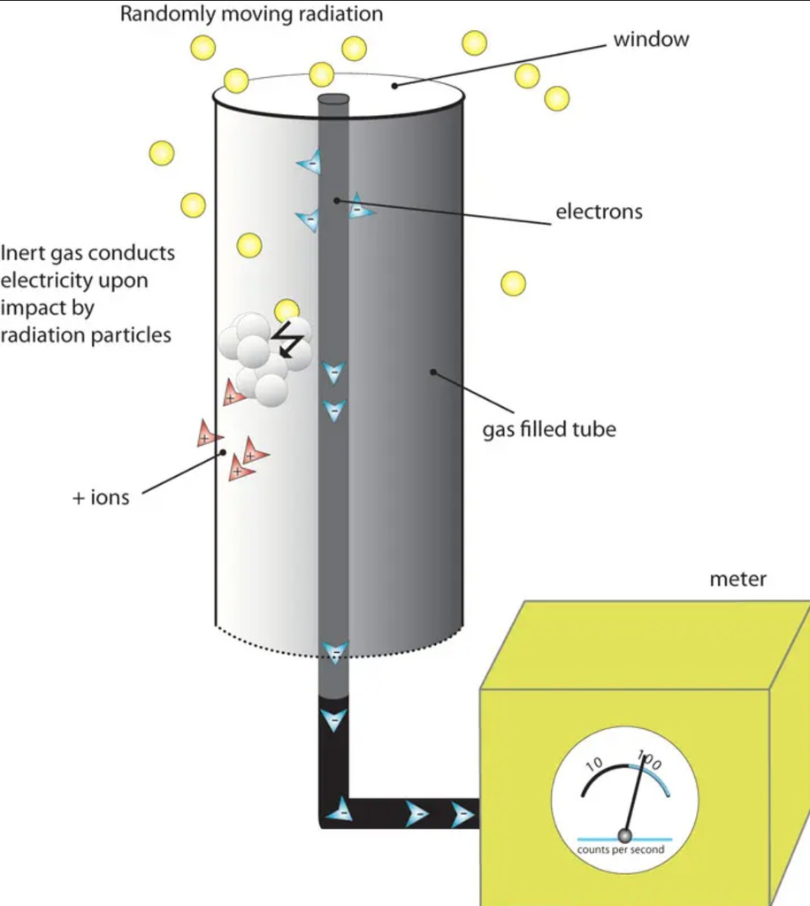

Figure 69: Gas-filled radiation detector illustrating the operating principles of a Geiger-Müller counter.

*Source: Linda Hall Library, [The Atomic Age: What Is a Geiger Counter and What Makes It Tick?](https://www.lindahall.org/experience/digital-exhibitions/the-atomic-age/02-it-s-a-question-of-physics/e-what-is-a-geiger-counter-and-what-makes-it-tick/).*

The number of pulses detected over a specified period is reported as a **count rate**, commonly expressed in counts per minute (CPM) or counts per second (CPS).

A higher count rate generally indicates that more radiation interactions are being detected under the same measurement conditions.

However, **a higher count rate does not automatically indicate a proportional increase in absorbed dose or equivalent dose**. The relationship depends on the radiation type, energy, detector response, geometry, and instrument calibration.

### Monitoring Alpha Radiation

Alpha particles have a relatively short range in air and can be stopped by materials such as paper or the outer layer of intact skin.

However, alpha-emitting radioactive material can be particularly hazardous if it enters the body through inhalation, ingestion, or a wound.

One way to monitor for airborne alpha-emitting radioactive material is to **collect particles from the air on a filter**.

The collected material can then be examined using an appropriate alpha radiation detector.

#### Continuous Air Monitoring

At nuclear facilities and other locations where radioactive material may be present, specialized instruments can continuously monitor the air for radioactive particles.

These instruments include **continuous particulate air monitors (CPAMs)** and **alpha continuous air monitors (alpha-CAMs)**.

They operate using a straightforward process:

1. **A pump draws air into the monitor.** Air from the surrounding environment enters the sampling system.
2. **A filter collects airborne particles.** If radioactive material is attached to these particles, it may also be collected.
3. **A radiation detector measures the collected material.** The instrument monitors radiation emitted by radioactive material on the filter.
4. **The instrument reports the measurement.** Changes in the detected radiation can help identify possible airborne radioactive contamination.

[figure not shown]

Figure 70: Continuous particulate air monitoring equipment used to detect airborne radioactive contamination.

*Image source: [Continuous Air Monitoring, YouTube](https://youtu.be/A93KgE9v8KA?si=cBcH1mq3fYOn5bB0).*

Some systems use a stationary filter, while others move the filter through the instrument.

**Why is this important?**

Natural background radiation is always present in our environment. Radiation monitoring systems must distinguish normal background levels from changes that could indicate a release of radioactive material.

**HazMat application:** Detecting radiation in an area and detecting radioactive contamination in the air are different tasks. Responders must select instruments and sampling methods appropriate for the hazard.

### Radioactive Materials Versus Radiation-Generating Equipment

Not all sources of ionizing radiation are radioactive materials.

It is important to distinguish between **radioactive materials** and **radiation-generating equipment**.

- **Radioactive materials:** Contain unstable atomic nuclei that release radiation as they decay. This process continues regardless of whether nearby equipment is powered on.
- **Radiation-generating equipment:** Devices such as X-ray machines produce radiation when energized. When a conventional X-ray machine is switched off, it stops producing X-rays.

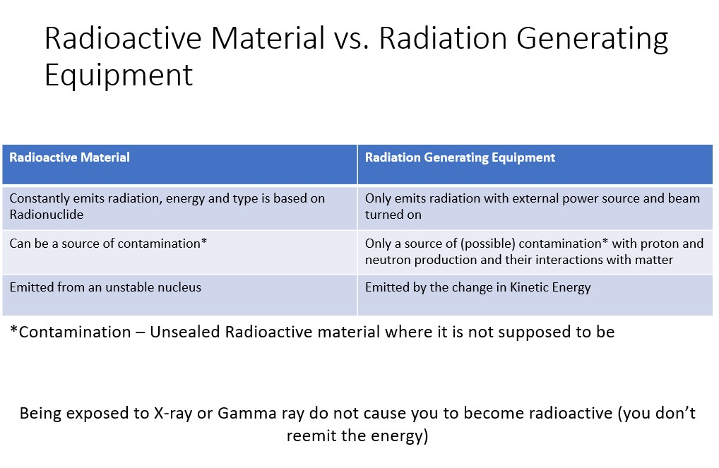

Figure 71: Comparison of radioactive materials and radiation-generating equipment.

*Source: NASA Armstrong Flight Research Center, Radiation Safety Office, Ionizing Radiation Safety Training.*

**Important distinction:** Being exposed to X-rays or gamma rays does not ordinarily cause a person to become radioactive.

For example, when a patient receives a conventional medical X-ray, radiation passes through the body and interacts with tissues. However, the patient does not become a radioactive source or continue emitting X-rays afterward.

### Fixed and Removable Radioactive Contamination

**Radioactive contamination** means radioactive material is present where it is not intended.

There are two important types of surface contamination:

- **Fixed contamination:** Radioactive material that adheres to a surface.
- **Removable contamination:** Radioactive material that can transfer to hands, clothing, tools, or other surfaces.

[figure not shown]

Figure 72: Comparison of fixed and removable radioactive contamination.

*Source: NASA Armstrong Flight Research Center, Radiation Safety Office, Ionizing Radiation Safety Training.*

Survey instruments and wipe tests help assess contamination, but the correct method depends on the radionuclide and detector.

**HazMat distinction:** Radiation exposure does not necessarily involve contamination. Removable contamination can create additional inhalation, ingestion, and spread hazards.

### Selecting Shielding Materials

Different types of radiation interact with matter in different ways. As a result, **the appropriate shielding material depends on the type and energy of radiation**.

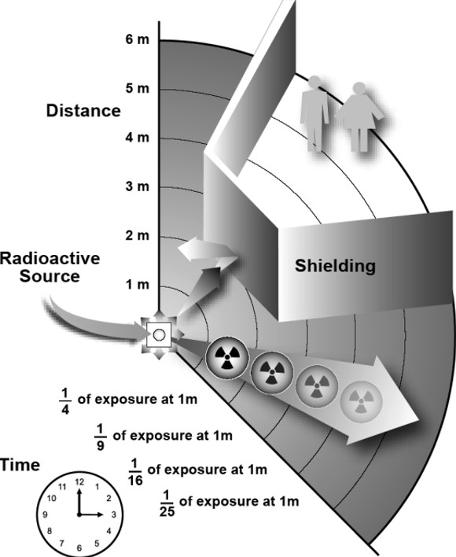

*Source: University of Washington, Radiation Safety Office.*

Some common shielding materials include:

- **Paper or clothing:** Can stop many alpha particles, although alpha-emitting radioactive material remains hazardous if inhaled or ingested.
- **Plastic:** Often useful for beta radiation because its relatively low atomic number can reduce the production of bremsstrahlung X-rays compared with high-atomic-number shielding.
- **Water and polyethylene:** Hydrogen-rich materials that can help slow fast neutrons.
- **Concrete:** Used for penetrating photon radiation and, with appropriate design, some neutron fields.
- **Lead:** Useful for attenuating many X-ray and gamma-ray fields.

**Important:** Shielding reduces radiation intensity, but it does not necessarily eliminate all radiation. Its effectiveness depends on radiation energy, material composition, thickness, and geometry.

#### How Does Shielding Reduce Radiation?

When X-rays or gamma rays pass through matter, they can interact with atoms in the shielding material.

These interactions reduce the intensity of radiation passing through the material.

Dense materials such as lead are commonly used for X-ray and gamma-ray shielding, while concrete can provide effective shielding when sufficient thickness is available.

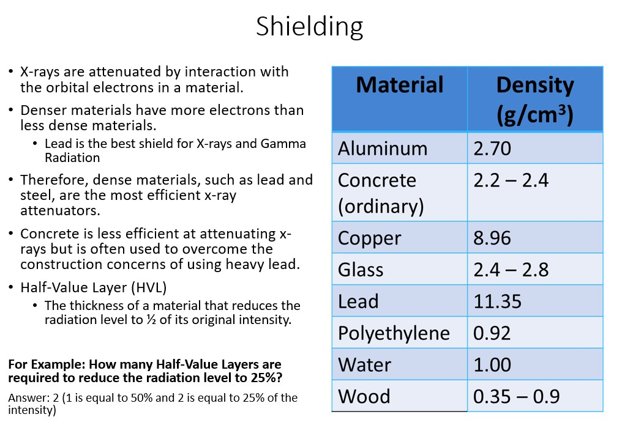

Figure 74: Radiation shielding materials and their densities.

*Source: NASA Armstrong Flight Research Center, Radiation Safety Office, Ionizing Radiation Safety Training.*

#### Half-Value Layer (HVL)

A **half-value layer (HVL)** is the thickness of a shielding material needed to reduce the intensity of a specified X-ray or gamma-ray beam to one-half of its original value.

For example, suppose a radiation beam passes through a material with a known half-value layer.

- **After one HVL:** 50% of the original intensity remains.
- **After two HVLs:** 25% of the original intensity remains.
- **After three HVLs:** 12.5% of the original intensity remains.

**Example:** How many half-value layers are needed to reduce the original radiation intensity to 25%?

After the first half-value layer:

$$100\%\times\frac{1}{2}=50\%$$

After the second half-value layer:

$$50\%\times\frac{1}{2}=25\%$$

**Answer: Two half-value layers.**

This example assumes a beam and shielding conditions for which the stated HVL applies.

#### Time, Distance, and Shielding

As discussed in the ALARA section, radiation protection relies on three fundamental principles:

1. **Time:** Minimize the time spent near a radiation source.
2. **Distance:** Increase the distance between yourself and the radiation source.
3. **Shielding:** Use appropriate materials to reduce the radiation reaching you.

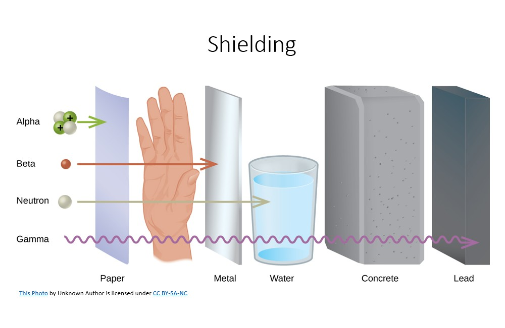

*Source: NASA Armstrong Flight Research Center, Radiation Safety Office, Ionizing Radiation Safety Training.*

For a small radioactive source under suitable conditions, radiation intensity decreases approximately with the square of the distance.

For example:

- At twice the original distance, the intensity is approximately one-fourth.
- At three times the original distance, the intensity is approximately one-ninth.

This is known as the **inverse-square law**.

**HazMat application:** Time, distance, and shielding help reduce external radiation exposure. However, a calculated dose or exposure time does not independently authorize entry into a hazardous area. Responders must use incident-specific monitoring, appropriate access controls, and qualified radiation safety oversight.

*Sources: Cember, H., & Johnson, T. E. Introduction to Health Physics (4th ed.); Bevelacqua, A. S., & Norman, L. A. Hazardous Materials Chemistry (3rd ed.).*

### Personal Radiation Dosimeters

How do radiation workers know how much radiation exposure they have received over time?

One way is through a **personal radiation dosimeter**, commonly called a **radiation badge**.

A radiation dosimeter is a small device worn by workers to monitor and record their exposure to ionizing radiation.

Radiation badges are commonly used in hospitals, nuclear facilities, research laboratories, and industrial workplaces where radiation exposure may occur.

[figure not shown]

Figure 76: Historical radiation safety poster reminding workers to wear their radiation monitoring badges.

*Source: U.S. Department of Energy, Richland Operations Office, historical radiation safety poster.*

#### How Does a Radiation Badge Work?

When ionizing radiation interacts with the material inside a dosimeter, it produces a measurable change.

Depending on the type of dosimeter, this change can be used to estimate the radiation dose received by the worker.

Common technologies include:

- **Optically Stimulated Luminescence (OSL):** Uses a material that stores information about radiation exposure and releases light when stimulated.
- **Thermoluminescent Dosimeters (TLDs):** Use materials that release light when heated after radiation exposure.
- **Electronic Dosimeters:** Can provide radiation dose measurements during use, with some models displaying readings in real time.

Radiation badges are worn according to the radiation safety program’s instructions. Their placement depends on the type of work, protective equipment, and monitoring requirements.

**Important:** A radiation badge does not shield a worker from radiation. It measures or records exposure so that radiation safety professionals can evaluate occupational dose.

Personal dosimeters also do not replace radiation survey instruments or contamination monitoring.

**HazMat application:** Radiation monitoring helps workers recognize exposure hazards, evaluate protective measures, and document occupational radiation doses.

*Sources: [Landauer, Understanding the Purpose of Radiation Badges and Personal Dosimetry](https://www.landauer.com/blog/understanding-purpose-radiation-badges-personal-dosimetry); Cember, H., & Johnson, T. E. Introduction to Health Physics (4th ed.).*

# Part IV. Non-Ionizing Radiation

## The Electromagnetic Spectrum

The **electromagnetic spectrum** describes the full range of electromagnetic radiation, organized according to wavelength and frequency.

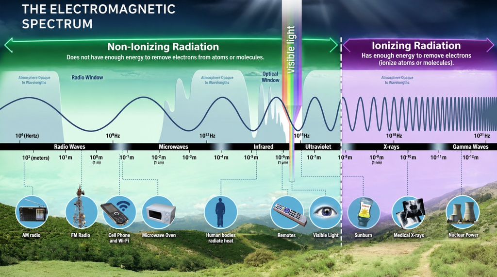

Electromagnetic spectrum illustrating the relationship between wavelength, frequency, and different types of electromagnetic radiation.

We have spent most of this lecture examining **ionizing radiation**, which has sufficient energy to remove electrons from atoms.

However, not all radiation is ionizing.

**Non-ionizing radiation** refers to electromagnetic radiation whose individual photons do not generally possess sufficient energy to remove electrons from atoms.

Although non-ionizing radiation does not produce ionization in the same way as X-rays or gamma rays, sufficiently intense exposure can still cause biological harm, including **tissue heating, skin burns, and eye injuries**.

Before examining the different types of non-ionizing radiation, we need to understand how electromagnetic radiation behaves.

## Electric and Magnetic Fields

Electromagnetic radiation involves two closely related concepts: **electric fields** and **magnetic fields**.

### Electric Fields

An **electric field** is a region where an electric charge experiences an electrical force.

- Electric fields are produced by electric charges.
- They occur around charged objects and energized electrical equipment.
- Electric field strength is commonly measured in volts per meter (V/m).

[figure not shown]

Figure 77: Illustration of an electric field.

*Source: [Science Facts, Electric Field](https://www.sciencefacts.net/electric-field.html).*

### Magnetic Fields

A **magnetic field** is a region where moving electric charges or magnetic materials experience magnetic forces.

- Magnetic fields are produced by magnets and moving electric charges, such as electric currents.
- They occur around magnets, electrical motors, and current-carrying wires.
- Magnetic field strength is commonly measured in tesla (T).

[figure not shown]

Figure 78: Illustration of a magnetic field.

*Source: [Encyclopaedia Britannica, How Do Magnets Work?](https://www.britannica.com/science/How-Do-Magnets-Work).*

**Important distinction:** An electric field exerts a force on charged particles whether they are stationary or moving, whereas the magnetic force on a charged particle depends on its motion.

In other words:

- **Electric fields:** Can exert forces on both stationary and moving electric charges.
- **Magnetic fields:** Exert forces on moving electric charges, but not on stationary electric charges.

*Source: Chemical Principles, Fundamentals A, discussion of electric and magnetic fields.*

### Electromagnetic Waves

Electric and magnetic fields are closely related.

**Electromagnetic radiation** consists of oscillating, or changing, electric and magnetic fields that travel through space and carry energy.

In an electromagnetic wave, the electric and magnetic fields oscillate perpendicular to one another and to the direction the wave travels.

[figure not shown]

Figure 79: Electromagnetic wave illustrating perpendicular oscillating electric and magnetic fields.

*Source: Chemical Principles, Fundamentals A, Figure A.8.*

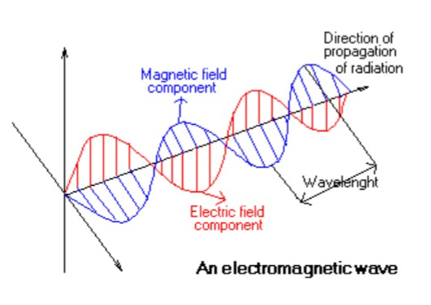

Figure 80: Illustration of an electromagnetic wave.

*Source: University of Washington, Department of Environmental & Occupational Health Sciences (DEOHS), ENVH 502, Dr. Michael Yost.*

Examples include radio waves, microwaves, visible light, ultraviolet radiation, X-rays, and gamma rays.

In a vacuum, all electromagnetic waves travel at the **speed of light**, represented by the symbol $c$:

$$c \approx 3.00 \times 10^8\ \mathrm{m/s}$$

This is approximately 300 million meters per second.

*Source: Chemical Principles, Section 1A.2, Electromagnetic Radiation.*

### Wavelength, Amplitude, and Frequency

Electromagnetic waves can be described using three important properties: **wavelength, amplitude, and frequency**.

#### Wavelength and Amplitude

- **Wavelength (**$\lambda$): The distance between corresponding points on successive waves, such as one peak to the next. Wavelength is commonly measured in meters (m).
- **Amplitude:** The maximum displacement of a wave from its center or equilibrium position. For an electromagnetic wave, this represents the strength of its oscillating electric or magnetic field.

The following illustration shows how wavelength and amplitude are represented in an electromagnetic wave.

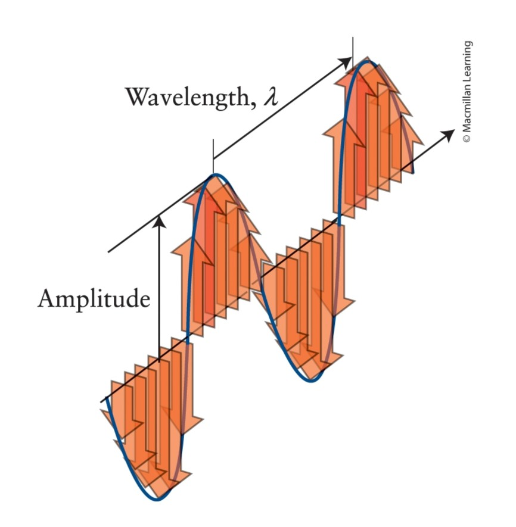

Figure 81: Electromagnetic wave illustrating wavelength and amplitude.

*Source: Chemical Principles, Section 1A.2, Electromagnetic Radiation, Figure 1A.7.*

The height of a wave can change without changing its wavelength or frequency.

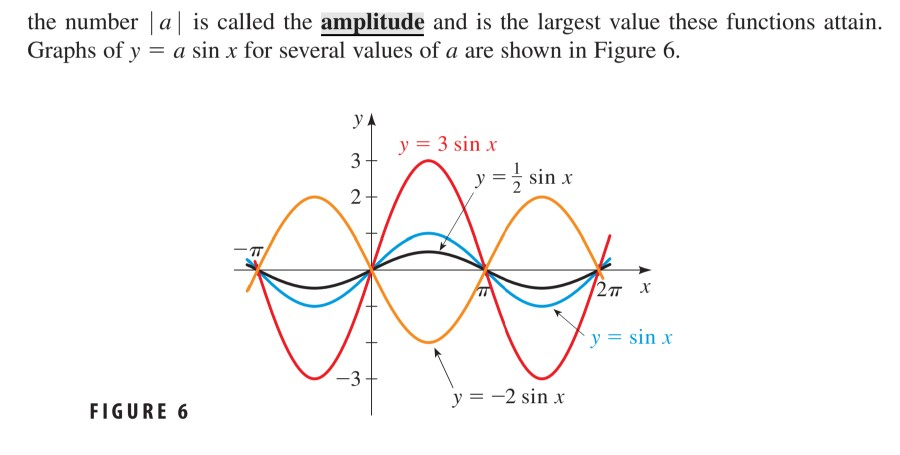

Figure 82: Sine waves with different amplitudes.

*Source: Stewart, Precalculus, trigonometric functions, Figure 6.*

#### Frequency and Wave Cycles

A wave completes one **cycle** when it returns to the same position and direction of motion.

The sine and cosine functions provide mathematical examples of repeating wave patterns.

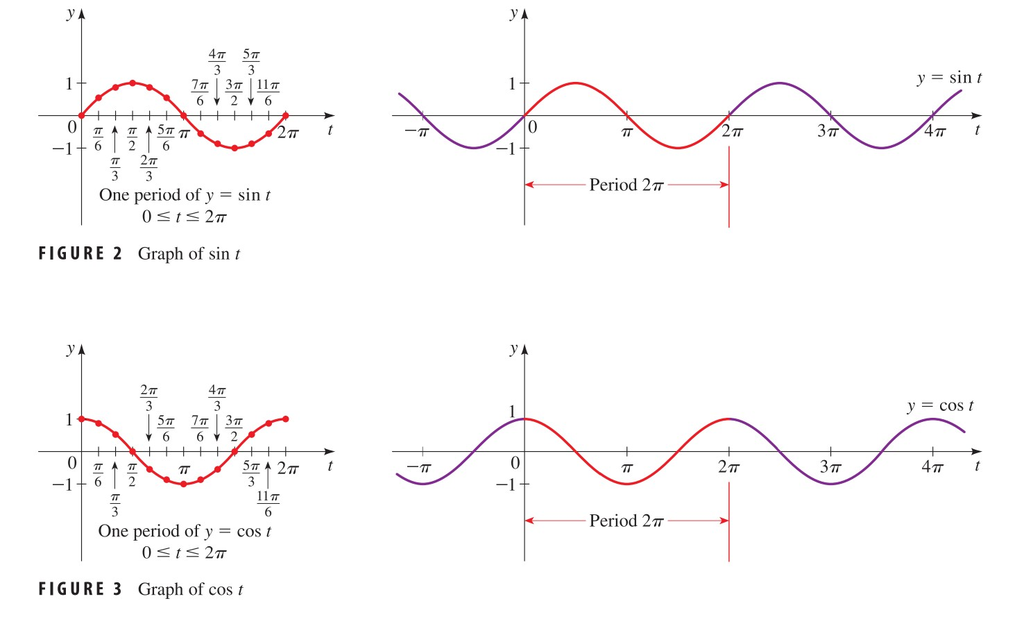

Figure 83: Graphs of sine and cosine functions illustrating repeating wave cycles and their periods.

*Source: Stewart, Precalculus, trigonometric functions, Figures 2 and 3.*

**Frequency (**$\nu$) is the number of complete wave cycles passing a point each second.

Frequency is measured in **hertz (Hz)**.

One hertz represents one cycle per second:

$$1\ \mathrm{Hz}=1\ \mathrm{s^{-1}}$$

#### Relationship Between Wavelength and Frequency

Wavelength and frequency are related through the **speed of light**.

Albert Einstein established that the speed of light in a vacuum is constant, regardless of the motion of the observer.

This speed is approximately:

$$c=3.00\times10^8\ \mathrm{m/s}$$

Because electromagnetic radiation travels at this constant speed in a vacuum, we can relate its wavelength and frequency using the following equation:

$$\boxed{c=\lambda\nu}$$

Where:

- $c$ = speed of light in a vacuum ($3.00\times10^8\ \mathrm{m/s}$)
- $\lambda$ = wavelength (m)
- $\nu$ = frequency (Hz or $\mathrm{s^{-1}}$)

**What does this equation tell us?**

Because electromagnetic waves travel at the same speed in a vacuum:

- **Shorter wavelengths** correspond to **higher frequencies**.
- **Longer wavelengths** correspond to **lower frequencies**.

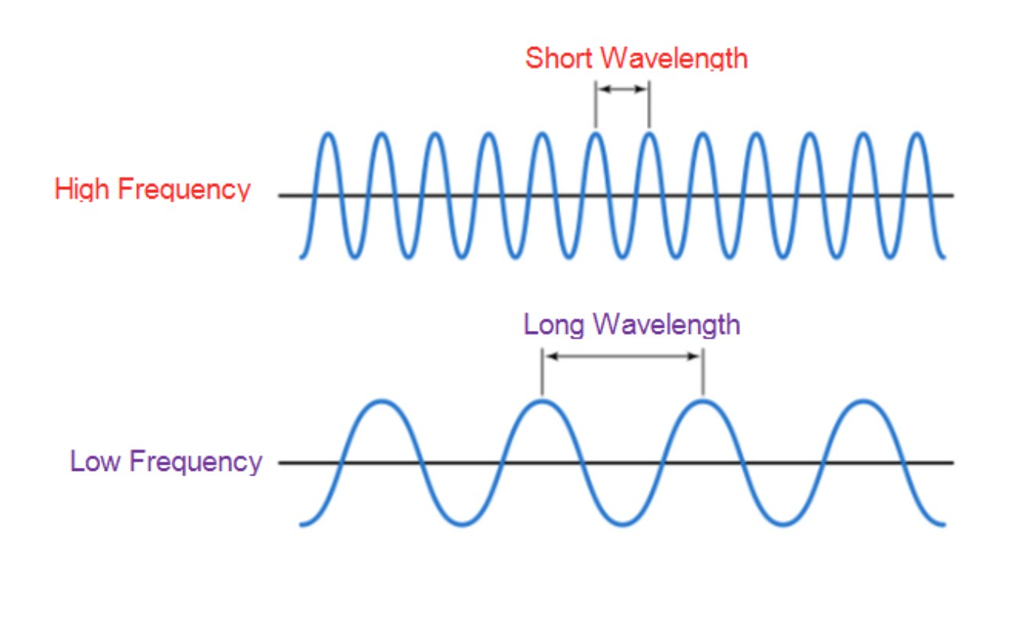

Figure 84: Comparison of high-frequency waves with short wavelengths and low-frequency waves with long wavelengths.

*Source: [Techplayon, Wavelength, Frequency, Amplitude and Phase: Defining Waves](https://www.techplayon.com/wavelength-frequency-amplitude-phase-defining-waves/).*

### Electromagnetic Energy

**Electromagnetic radiation** carries energy through space in the form of oscillating electric and magnetic fields.

Electromagnetic radiation is a natural phenomenon that has existed since the beginning of the universe. **Visible light** is one of its most familiar forms.

Electromagnetic fields (EMF) are among the most widespread environmental influences associated with modern technology.

Electromagnetic fields occur across a broad range of frequencies, from static electric and magnetic fields to radiofrequency radiation and higher-frequency electromagnetic radiation.

Today, populations are exposed to varying levels of electromagnetic fields from both natural and human-made sources.

As technology advances, the number of potential sources of electromagnetic field exposure continues to increase.

#### Frequency and Electromagnetic Energy

As we learned earlier, electromagnetic waves are characterized by their wavelength ($\lambda$) and frequency ($\nu$).

An important relationship is that **higher-frequency electromagnetic radiation carries more energy per photon**.

Moving from radio waves toward gamma rays:

- **Wavelength decreases.**
- **Frequency increases.**
- **Energy per photon increases.**

The non-ionizing portion of the spectrum includes radio waves, microwaves, infrared radiation, visible light, and most ultraviolet radiation.

**Remember:** The boundary between ionizing and non-ionizing electromagnetic radiation is not perfectly defined by a single wavelength. The ability to ionize matter depends on photon energy and the material involved.

#### Occupational and Environmental Health Relevance

Understanding electromagnetic fields is important because workers may encounter EMF from electrical equipment, communication systems, industrial machinery, and other technological sources.

However, **exposure to an electromagnetic field does not automatically mean that a harmful health effect will occur**.

The potential for adverse health effects depends on factors such as the frequency, field strength, exposure duration, and interaction with biological tissues.

*Sources: [World Health Organization, Electromagnetic Fields](https://www.who.int/health-topics/electromagnetic-fields#tab=tab_1); Chemical Principles, Section 1A.2, Electromagnetic Radiation; NASA Armstrong Flight Research Center, Radio Frequency Safety Training.*

## Radio Waves (30 kHz to 3 GHz)

**Radio waves** are low-frequency, low-energy electromagnetic waves with the longest wavelengths in the electromagnetic spectrum. Their wavelengths range from approximately the length of a football to distances larger than our planet.

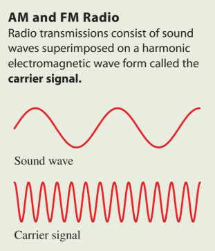

In 1888, **Heinrich Hertz** experimentally demonstrated the existence of radio waves using electrical sparks to generate and detect electromagnetic signals.

Commercial radio broadcasting began in 1920. Later, in 1932, **Karl Jansky**, working at Bell Laboratories, discovered radio waves originating beyond Earth. His discovery helped establish **radio astronomy**, which eventually allowed scientists to study objects and phenomena such as pulsars, plasma clouds, and quasars.

Today, we use radio waves every day for:

- Cellular networks and smartphones
- Wi-Fi and Bluetooth
- Global Positioning System (GPS)
- Radio broadcasting (AM/FM stations)
- Radar and weather tracking
- Satellite and deep-space communications
- Radio astronomy

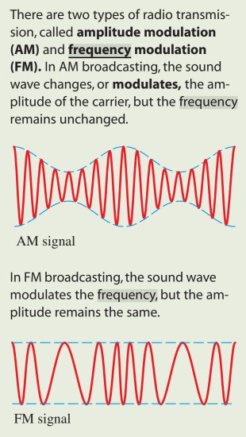

Figure 86: Illustration comparing amplitude modulation and frequency modulation of radio waves.

### Supplementary Video: Radio Waves

The following video provides an additional visual resource for understanding radio waves and their applications.

[video not shown]

*Video source: [Watch on YouTube](https://youtu.be/OzDmEA8x0nQ?si=1gssjjPcFxlJBiZR).*

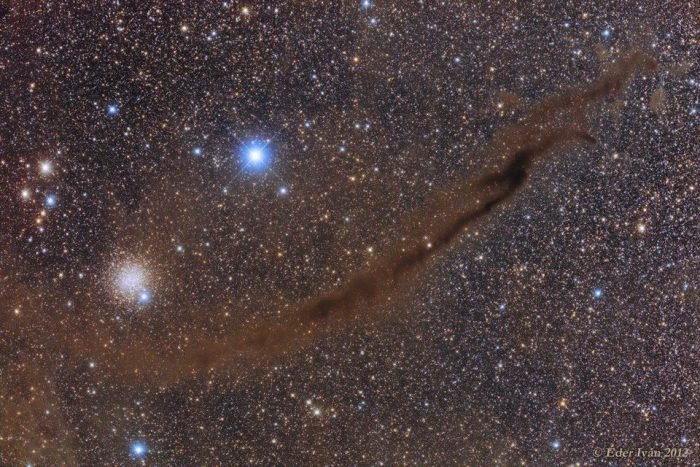

*Image source: [NASA Astrobiology, First Mapping of Interstellar Clouds in Three Dimensions](https://astrobiology.nasa.gov/news/first-mapping-of-interstellar-clouds-in-three-dimensions/).*

*Sources: NASA, Tour of the Electromagnetic Spectrum (NASA-tour-of-the-ems.pdf); [Supplementary video](https://youtu.be/HPcAWNlVl-8?si=h60FAI7_wv9AN9xZ).*

**Radio frequency (RF) radiation** is electromagnetic energy used in wireless communication and other technologies.

- **Where encountered:** Radio transmitters, communication towers, antennas, radar equipment, and industrial RF systems.
- **Primary occupational hazards:** Sufficiently intense RF exposure can produce tissue heating and injury.
- **Safety consideration:** Workers must identify active transmitters and follow RF exposure controls.

### Antennas

An **antenna** is a device that transmits or receives electromagnetic waves.

- **Omnidirectional antennas:** Radiate energy in many directions around the antenna, generally across the horizontal plane.
- **Directional antennas:** Concentrate radiated energy in particular directions, such as radar antennas and satellite dishes.

#### How Does RF Transmission Work?

A radio transmitter supplies an alternating electrical current to an antenna.

As the current oscillates, it produces changing electric and magnetic fields. Some of this energy travels away from the antenna as **electromagnetic radiation**.

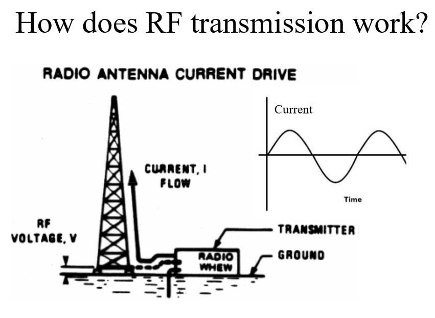

Figure 88: Radio antenna driven by an alternating electrical current.

*Source: University of Washington, Department of Environmental & Occupational Health Sciences, ENVH 502, Dr. Michael Yost.*

#### Radio-Wave Propagation

**Propagation** describes how electromagnetic waves travel away from their source.

As radio waves propagate, they carry energy through oscillating electric and magnetic fields.

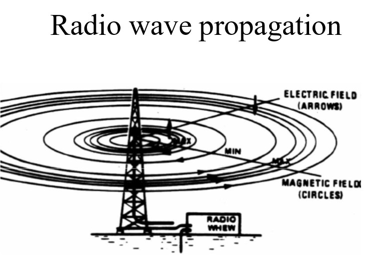

Figure 89: Radio-wave propagation from a transmitting antenna.

*Source: University of Washington, Department of Environmental & Occupational Health Sciences, ENVH 502, Dr. Michael Yost.*

#### Near Field and Far Field

The electromagnetic field surrounding an antenna changes with distance.

Two important regions are the **near field** and **far field**.

- **Near field:** The region close to an antenna where electric and magnetic fields have a complex relationship and some energy may be temporarily stored in the fields.
- **Far field:** The region sufficiently far from the antenna where electromagnetic waves behave more predictably and the electric and magnetic fields are perpendicular to each other and to the direction of propagation.

##### Two Regions of the Near Field

The near field can be divided into two regions:

1. **Reactive near field:** The region closest to the antenna, where energy is temporarily stored in the electric and magnetic fields and exchanged with the antenna rather than being entirely radiated away.
2. **Radiative near field (Fresnel region):** A region farther from the antenna where energy propagates outward, but the radiation pattern and field distribution still depend on distance and antenna geometry.

Beyond the near field is the **far field (Fraunhofer region)**, where the radiation pattern becomes more stable with distance.

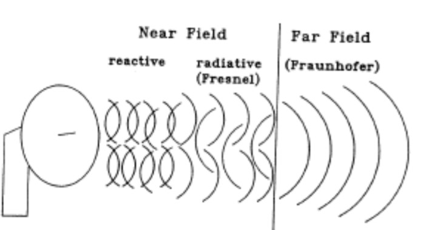

Figure 90: Illustration of reactive near field, radiative near field, and far field surrounding an antenna.

*Source: University of Washington, Department of Environmental & Occupational Health Sciences (DEOHS), ENVH 502, Dr. Michael Yost.*

##### Inverse-Square Law

In the far field of an antenna, under idealized conditions, **power density decreases approximately with the square of the distance from the source**.

$$\boxed{S \propto \frac{1}{r^2}}$$

Where:

- $S$ = electromagnetic power density (W/m²)
- $r$ = distance from the source (m)

**What does this mean?**

If the distance from an antenna doubles, the power density decreases to approximately **one-fourth** of its original value, assuming the same transmission direction and far-field conditions.

**Important:** The inverse-square relationship should not automatically be applied to near-field exposures or complex antenna configurations.

*Source: Cember & Johnson, Introduction to Health Physics (4th ed.), Chapter 14, discussion of antenna radiation zones.*

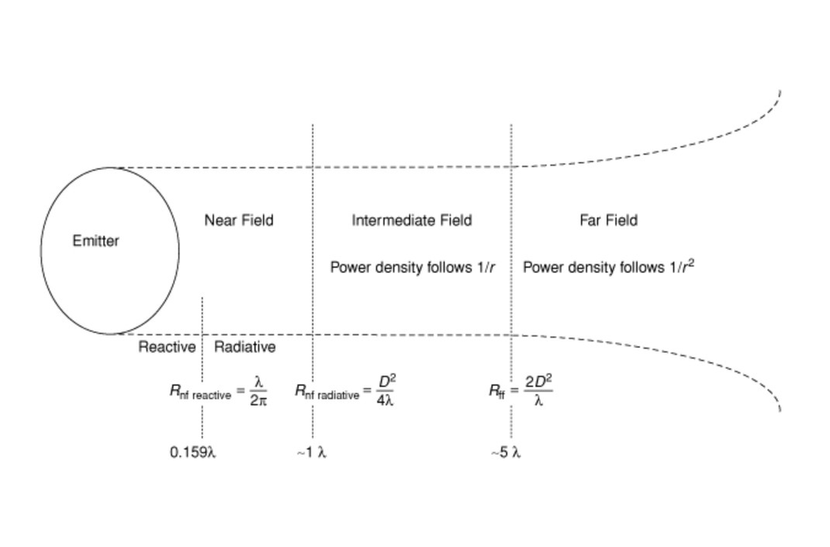

Figure 91: Near-field, intermediate-field, and far-field regions surrounding an antenna.

*Source: Cember & Johnson, Introduction to Health Physics (4th ed.), Figure 14-12.*

### Interaction of RF Radiation with Matter

When electromagnetic radiation encounters matter, several interactions are possible:

- **Transmission:** Energy passes through the material.
- **Absorption:** Energy is transferred to the material.
- **Reflection:** Energy is redirected from a surface.
- **Scattering:** Energy is redirected in different directions.

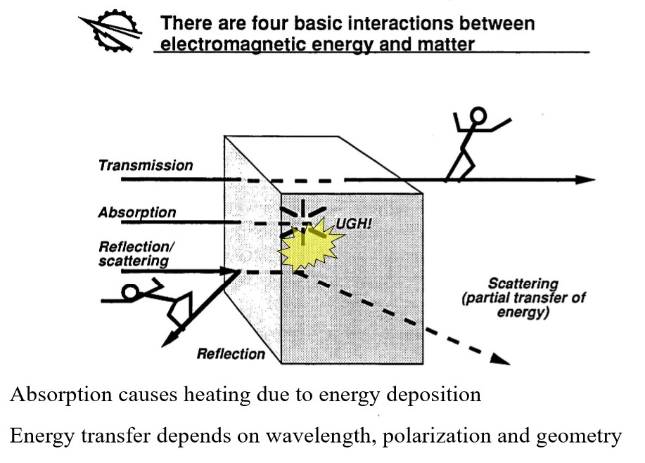

Figure 92: Interactions between electromagnetic radiation and matter.

*Source: University of Washington, Department of Environmental & Occupational Health Sciences (DEOHS), ENVH 502, Dr. Michael Yost.*

For occupational health, **absorption is especially important** because absorbed RF energy can produce heating in biological tissues.

### Specific Absorption Rate (SAR)

**Specific absorption rate (SAR)** describes the rate at which electromagnetic energy is absorbed per unit mass of biological tissue.

$$\boxed{\mathrm{SAR}=\frac{\Delta E}{m\Delta t}}$$

Where:

- $\mathrm{SAR}$ = specific absorption rate (W/kg)
- $\Delta E$ = energy absorbed by tissue (J)
- $m$ = mass of tissue (kg)
- $\Delta t$ = duration of energy absorption (s)

Because one watt equals one joule per second:

$$1\ \mathrm{W/kg}=1\ \mathrm{J/(kg\cdot s)}$$

**Why is SAR important?**

SAR helps describe how much RF energy is absorbed by the body.

The amount and distribution of absorbed energy depend on the frequency, tissue properties, body geometry, and orientation relative to the electromagnetic field.

*Source: Cember & Johnson, Introduction to Health Physics (4th ed.), Section 14, Equations 14.46–14.48.*

### Biological Effects of RF Exposure

The primary established hazard of sufficiently intense RF exposure is **tissue heating**.

- **Internal tissue heating:** Absorbed RF energy can raise tissue temperature and cause thermal injury.
- **Eye injuries:** Excessive RF exposure may damage sensitive eye tissues, including the lens.
- **Skin heating:** At higher RF frequencies, energy is increasingly absorbed near the body’s surface, potentially causing burns.

**Important:** RF energy can produce tissue heating without an immediately noticeable sensation of warmth or pain.

**Application:** An antenna does not need to produce visible light or movement to transmit RF energy. Before approaching transmitting equipment, workers and responders should verify operating conditions, identify restricted areas, and follow established RF safety procedures.

*Sources: Cember & Johnson, Introduction to Health Physics (4th ed.), Chapter 14; NASA Armstrong Flight Research Center, Radio Frequency Safety Training.*

## Microwaves (300 MHz to 300 GHz)

**Microwaves** are a portion of the electromagnetic spectrum within the radiofrequency (RF) range, between longer-wavelength radio waves and infrared radiation.

Different microwave frequencies are grouped into **bands**, which are used for different technological applications.

- **L-band:** Used in GPS navigation and certain radar and satellite systems. Longer wavelengths can penetrate vegetation and provide information about soil moisture.
- **S-band:** Used in weather radar, satellite communications, and microwave ovens.
- **C-band:** Used in radar, satellite communications, and Earth observation. Certain C-band radar systems can observe the Earth’s surface through clouds and some vegetation.
- **X-band:** Used in radar systems, including weather monitoring, high-resolution Earth observation, and speed radar guns.
- **Ku-band:** Used extensively in satellite communications, including television and data transmission.

[figure not shown]

Figure 93: Police speed radar gun used to measure vehicle speed.

*Image source: [Stalker Radar, Police Radar Gun SI](https://stalkerradar.com/international/police-radar-gun-si/).*

### How Do Microwave Ovens Work?

Microwave ovens typically operate at approximately **2.45 GHz**, corresponding to a wavelength of approximately **12.2 centimeters**.

Microwaves interact with polar molecules, particularly water, and dissolved ions within food.

The oscillating electric field causes polar molecules to continually reorient and charged particles to move. These interactions transfer electromagnetic energy into the food, producing **heat**.

### Occupational Health Hazards

Microwave radiation is **non-ionizing**, meaning its individual photons do not have sufficient energy to ionize atoms through the mechanisms associated with X-rays or gamma rays.

The primary established hazard of sufficiently intense microwave exposure is **tissue heating**.

- **Thermal injury:** Excessive absorption of microwave energy can raise tissue temperature and cause burns or internal heating.
- **Eye injuries:** The lens of the eye has limited blood circulation and is particularly vulnerable to excessive heating. Severe exposure may contribute to cataract formation.
- **Testicular heating:** Excessive temperature increases can temporarily interfere with sperm production because normal testicular function depends on temperatures below core body temperature.

The amount of energy absorbed depends on microwave frequency, exposure intensity, duration, and the electrical properties of the exposed tissues.

**Safety consideration:** Microwave radiation does not produce radioactive contamination. When evaluating high-powered microwave equipment, workers should consider the potential for RF exposure, equipment operating conditions, and established safety controls.

*Sources: Cember, H., & Johnson, T. E., Introduction to Health Physics (4th ed.), Chapter 14, discussion of RF and microwave biological effects; NASA, Tour of the Electromagnetic Spectrum.*

## Infrared Radiation (IR) ($1000\ \mu\mathrm{m}$ to $0.7\ \mu\mathrm{m}$)

**Infrared radiation (IR)** is electromagnetic radiation with wavelengths longer than visible red light and shorter than microwaves.

Although infrared radiation is invisible to the human eye, we can experience some of its energy as **radiant heat**, such as the warmth felt when standing near a fire.

Infrared radiation is commonly divided into three regions: **near-infrared, mid-infrared, and far-infrared**.

[figure not shown]

Figure 94: Radiant heat emitted by a fire.

*Source: Hazardous Materials Chemistry textbook.*

### Types of Infrared Radiation and Their Applications

#### Near-Infrared (0.7–3 $\mu\mathrm{m}$)

Near-infrared radiation has wavelengths closest to visible red light.

- **Common sources:** Sunlight, incandescent lamps, and certain infrared LEDs and lasers.
- **Applications:** Night-vision equipment, infrared illumination, optical sensors, and some communication systems.
- **Occupational hazards:** Intense near-infrared exposure can injure the eyes, particularly because some wavelengths can reach the retina.

#### Mid-Infrared (3–30 $\mu\mathrm{m}$)

Mid-infrared radiation is strongly associated with thermal emission and molecular absorption.

- **Common sources:** Heated equipment, industrial furnaces, and other warm or hot surfaces.
- **Applications:** Thermal imaging, gas detection, infrared spectroscopy, and industrial temperature measurements.
- **Occupational hazards:** Intense exposure can produce heating of the skin and anterior structures of the eye.

#### Far-Infrared (30–1000 $\mu\mathrm{m}$)

Far-infrared radiation consists of longer-wavelength infrared energy.

- **Common sources:** Warm surfaces, heating equipment, and thermal radiation from the environment.
- **Applications:** Radiant heating systems, thermal sensing, and certain scientific instruments.
- **Occupational hazards:** Excessive exposure can cause superficial tissue heating, skin burns, and heat strain.

**Note:** The wavelength boundaries between near-, mid-, and far-infrared vary among scientific and technical classification systems.

### Biological Effects of Infrared Radiation

A **biological effect** is a response of living tissue to an environmental exposure. However, not every biological effect is harmful.

For example, feeling warmth from a fire is a normal biological response to infrared radiation.

A biological effect becomes harmful when the absorbed energy produces tissue damage or overwhelms the body’s ability to regulate temperature.

The primary established mechanism of injury from excessive infrared exposure is **thermal heating**.

- **Skin:** Excessive radiant energy can increase skin temperature, producing discomfort, burns, or other thermal injuries.
- **Eyes:** Intense infrared radiation can injure ocular tissues. Depending on wavelength and exposure conditions, the cornea, lens, or retina may be affected. Chronic occupational exposure to intense infrared radiation has also been associated with cataracts.
- **Heat strain:** Infrared radiation from furnaces, molten materials, and other high-temperature sources can increase a worker’s total heat load, particularly when environmental temperatures are elevated.

### Occupational and Environmental Health Relevance

Workers may encounter infrared radiation in foundries, glass manufacturing, welding operations, firefighting, industrial heating, and other high-temperature environments.

**Safety consideration:** Infrared radiation is non-ionizing. Its primary established occupational hazard is excessive heating of biological tissues, not radioactive contamination.

Exposure assessments should consider the intensity of the radiation, exposure duration, distance from the source, wavelength, and effectiveness of protective controls.

### Additional Applications of Infrared Radiation

- **Thermal imaging:** Infrared cameras detect differences in emitted thermal radiation, allowing scientists and firefighters to observe temperature patterns and identify hotspots during wildfires.
- **Earth observation:** NASA satellites use infrared measurements to monitor land and sea surface temperatures, vegetation conditions, and fires.
- **Vegetation monitoring:** Near-infrared light reflected by plants helps scientists assess vegetation health because healthy leaves reflect substantial near-infrared radiation.
- **Astronomy:** Infrared telescopes, including the James Webb Space Telescope, can observe cooler astronomical objects and detect light from regions obscured by interstellar dust.

*Source: NASA, Tour of the Electromagnetic Spectrum, Infrared Waves and Reflected Near-Infrared Waves.*

*Sources: Cember, H., & Johnson, T. E., Introduction to Health Physics (4th ed.), Chapter 14, discussion of biological and thermal effects of non-ionizing radiation; Hazardous Materials Chemistry textbook.*

## Ultraviolet Radiation (UV)

**Ultraviolet (UV) radiation** lies between visible light and X-rays on the electromagnetic spectrum.

- Common sources include sunlight, welding arcs, germicidal lamps, and some industrial processes.
- UV radiation can cause sunburn, photokeratitis (welder’s flash), and DNA damage.
- Repeated or excessive exposure to certain UV wavelengths increases the risk of skin cancer.

Unlike radiofrequency and microwave radiation, **UV radiation can produce significant photochemical effects without substantial tissue heating**.

[figure not shown]

Figure 95: Clinical examples of skin cancer, including Merkel cell carcinoma, squamous cell carcinoma, basal cell carcinoma, and melanoma.

*Source: [Mayo Clinic, Skin Cancer: Symptoms and Causes](https://www.mayoclinic.org/diseases-conditions/skin-cancer/symptoms-causes/syc-20377605).*

### Additional Applications of Ultraviolet Radiation

- **Ozone monitoring:** Satellite instruments measure ultraviolet radiation to study atmospheric ozone, which absorbs much of the Sun’s harmful UV radiation.
- **Solar and astronomical observations:** Ultraviolet imaging helps scientists study the Sun, hot stars, and energetic processes that may be difficult to observe in visible light.
- **Auroral observations:** Ultraviolet imaging can reveal auroras produced when energetic charged particles interact with gases in a planet’s atmosphere.

*Source: NASA, Tour of the Electromagnetic Spectrum, Ultraviolet Waves.*

## Lasers

**LASER** stands for *Light Amplification by Stimulated Emission of Radiation*.

A laser produces a concentrated beam of electromagnetic radiation, commonly in the ultraviolet, visible, or infrared portions of the spectrum.

- Lasers are used in medicine, manufacturing, research, surveying, and aerospace applications.
- Depending on wavelength and power, laser exposure can damage the eyes or skin.
- Laser safety controls include beam enclosures, restricted access, training, and protective eyewear selected for the laser’s wavelength and optical density.

**Important:** A laser beam does not have to be visible to be hazardous. Infrared laser radiation, for example, may be invisible while still presenting a serious eye hazard.

### Additional Applications of Lasers

- **Distance measurement:** Laser ranging instruments measure distance by transmitting light and measuring its return from a target.
- **Atmospheric research:** Lidar (light detection and ranging) systems use laser pulses to study aerosols, clouds, and other atmospheric properties.
- **Remote sensing:** Airborne and satellite-based laser instruments can measure surface elevation, vegetation structure, and changes in ice or terrain.

[figure not shown]

Figure 96: ISS Space Sky Laser illustration.

*Image source: [ISS Space Sky Laser, Wikipedia](https://en.wikipedia.org/wiki/ISS_Space_Sky_Laser).*

*Sources: NASA, Earth-observing lidar applications; NASA Armstrong Flight Research Center, Laser Safety Training.*

## Final Considerations: Radiation Safety

Both ionizing and non-ionizing radiation can present occupational hazards, but their mechanisms of interaction with matter differ.

- **Ionizing radiation:** Can remove electrons from atoms, producing ions and potentially damaging biological molecules.
- **Non-ionizing radiation:** Can cause heating, photochemical injury, or other biological effects depending on frequency, intensity, and exposure conditions.
- **Radiation protection:** Requires understanding the source, evaluating the exposure, and selecting controls appropriate to the hazard.

**The central lesson:** Identifying a source as ionizing or non-ionizing is only the beginning of a radiation hazard assessment. Understanding how that radiation interacts with matter helps us predict potential hazards and make informed safety decisions.

*Sources: NASA Armstrong Flight Research Center, Radio Frequency Safety Training; NASA Armstrong Flight Research Center, Laser Safety Training; Cember, H., & Johnson, T. E. Introduction to Health Physics (4th ed.).*

# Source-Page Appendix

This appendix identifies the principal textbooks, educational materials, institutional training resources, regulatory references, and third-party figures used in developing Lecture 04.

Source citations accompanying individual figures, examples, and discussions throughout the lecture provide additional attribution. References listed here do not imply that all third-party materials are available under the course’s Creative Commons license.

## Referenced Textbooks and Educational Sources

1. Burdge, Julia, and Jason Overby. *Chemistry: Atoms First*, 2nd edition. Chapter 2, **Atoms and the Periodic Table**, and Chapter 20, **Nuclear Chemistry**. Used for atomic structure, isotopes, nuclear stability, radioactive decay, natural radioactivity, technetium-99m, and biological effects of ionizing radiation. Specific references include Chapter 20, Table 20.1 and Figure 20.2.
2. Atkins, Peter, Loretta Jones, Leroy Laverman, James Patterson, and Michael Young. *Chemical Principles*, 8th edition. **Focus 9: Nuclear Chemistry**, **Fundamentals A**, **Section 1A.2: Electromagnetic Radiation**, and **Section 7B.2: Half-Lives for First-Order Reactions**. Used for nuclear radiation classifications, radioactive decay, electric and magnetic fields, electromagnetic waves, wavelength, frequency, and the mathematical description of first-order decay. Figures referenced include A.8 and 1A.7.
3. Bevelacqua, Armando S., and Laurie A. Norman. *Hazardous Materials Chemistry*, 3rd edition. Jones & Bartlett Learning. Chapter 3, **Atomic and Nuclear Structure and Radiation**. Used for alpha, beta, and gamma radiation, radiation penetration, shielding, radioactive materials, biological effects, and hazardous materials response applications.
4. Cember, Herman, and Thomas E. Johnson. *Introduction to Health Physics*, 4th edition. Used for radioactive decay, physical and effective half-life, ionization, biological effects, radiation dosimetry, detection instruments, shielding, and radiation protection. Chapter 14 was also consulted for radiofrequency radiation, antennas, radiation zones, microwave exposure, and thermal effects of non-ionizing radiation.
5. Stewart, James, Lothar Redlin, and Saleem Watson. *Precalculus: Mathematics for Calculus*, 6th edition. Chapter 4, **Exponential and Logarithmic Functions**, particularly Section 4.6 and Example 6. Used to introduce exponential decay, natural logarithms, half-life calculations, and the mathematical relationship between the decay constant and half-life. Material on trigonometric functions, including Figures 2, 3, and 6, was also used to illustrate periodic waves, amplitude, and repeating cycles.
6. **Study.com educational materials.** Consulted during preliminary lecture development. Specific lessons, authors, and URLs should be documented before retaining these materials as formal references in a publicly distributed version.

## NASA Educational and Training Resources

1. **National Aeronautics and Space Administration (NASA).** [*Introduction to the Electromagnetic Spectrum*](https://science.nasa.gov/ems/01_intro/). Used to introduce electromagnetic radiation and its relationship to the electromagnetic spectrum.
2. **NASA.** *Tour of the Electromagnetic Spectrum*. Used for radio waves, microwaves, infrared radiation, reflected near-infrared radiation, ultraviolet radiation, and scientific applications of electromagnetic radiation. Applications discussed include thermal imaging, wildfire detection, vegetation monitoring, atmospheric observations, astronomy, and planetary auroras.
3. **NASA Armstrong Flight Research Center (AFRC), Radiation Safety Office.** *Ionizing Radiation Safety Training*. Instructor-provided training materials used for radiation protection principles, radiation detection instruments, occupational dose limits, contamination, shielding, and radiation safety practices.
4. **NASA Armstrong Flight Research Center (AFRC).** *Radio Frequency Safety Training*. Instructor-provided training materials used for radiofrequency radiation, antennas, occupational exposure considerations, and non-ionizing radiation safety.
5. **NASA Armstrong Flight Research Center (AFRC).** *Laser Safety Training* (2021). Instructor-provided training materials used for laser hazards, eye and skin injuries, laser classifications, protective eyewear, warning signs, and engineering and administrative controls.
6. **NASA Earth Science and Earth-observing missions.** Educational materials concerning lidar and remote sensing. Used for applications involving atmospheric aerosols, clouds, surface elevation, vegetation structure, and environmental observations. Specific mission and webpage references should be added when finalized.

## University of Washington Educational and Radiation Safety Resources

1. **University of Washington, Environmental Health & Safety (EH&S), Radiation Safety Office.** *Ionizing Radiation Safety* training materials. Used for internal and external radiation exposure, radiation monitoring, contamination, and radiation protection practices.
2. **University of Washington, Environmental Health & Safety.** *Ionizing Radiation Safety: Internal Radiation*, Philip Campbell, CHP, Spring 2022. Used for internal radiation exposure and associated biological considerations.
3. **University of Washington, Environmental Health & Safety.** *Ionizing Radiation Safety: External Radiation* (2022). Used for external exposure, radiation protection, and shielding.
4. **University of Washington, Environmental Health & Safety.** Training materials discussing activity in organs and tissues and effective decay constants, particularly pages 19–20. Used for biological retention and effective half-life.
5. **University of Washington, Department of Environmental & Occupational Health Sciences (DEOHS).** ENVH 502 instructional materials, Dr. Michael Yost. Used for electromagnetic fields, radiofrequency radiation, antennas, and non-ionizing radiation exposure concepts.
6. **University of Washington, Environmental Health & Safety.** Background radiation instructional materials, November 12, 2026. Used for contextual comparisons of natural and other radiation exposures.

## Public Health, Scientific, and Government References

The following organizations and publications provide supporting information for the lecture’s discussions of environmental radiation, biological effects, radiation monitoring, and public health.

- **U.S. Environmental Protection Agency (EPA):** [Radiation Sources and Doses](https://www.epa.gov/radiation/radiation-sources-and-doses), including average U.S. exposure estimates and information attributed to NCRP Report No. 160.
- **National Council on Radiation Protection and Measurements (NCRP):** *Report No. 160, Ionizing Radiation Exposure of the Population of the United States* (2009). Used for background radiation and population exposure comparisons.
- **U.S. Geological Survey (USGS):** [What Is Radon?](https://www.usgs.gov/faqs/what-radon) and *Generalized Geologic Radon Potential of the United States*, based on Open-File Report 93-292 (1993). Used for radon formation, geology, and environmental distribution.
- **U.S. Environmental Protection Agency (EPA):** [How Does Radon Get Into Your Home?](https://www.epa.gov/radon/how-does-radon-get-your-home) and [Radioactivity in Tobacco](https://www.epa.gov/radtown/radioactivity-tobacco). Used for environmental exposure pathways.
- **Centers for Disease Control and Prevention (CDC):** [Radon in the Home](https://www.cdc.gov/radon/about/radon-home.html), [Iodine-131](https://www.cdc.gov/radiation-emergencies/hcp/isotopes/iodine-131.html), [Potassium Iodide (KI)](https://www.cdc.gov/radiation-emergencies/treatment/potassium-iodide.html), and [Facts About Cigarette Smoking and Radiation](https://www.cdc.gov/radiation-health/data-research/facts-stats/cigarette-smoking.html). Used for radiation exposure pathways, internal contamination, thyroid uptake of radioactive iodine, and public health applications.
- **Connecticut Department of Public Health:** [Radon in Water](https://portal.ct.gov/dph/environmental-health/radon/radon-in-water?language=en_US). Used for discussion of radon in drinking water.
- **National Research Council, Committee to Assess Health Risks from Exposure to Low Levels of Ionizing Radiation:** *BEIR VII: Health Risks from Exposure to Low Levels of Ionizing Radiation*. National Academies Press, 2005. Table 7-9. Used for discussion of radiation-related health risks. The referenced table is reproduced with permission from the National Academies Press, as noted at its location in the lecture.
- **World Health Organization (WHO):** [Electromagnetic Fields](https://www.who.int/health-topics/electromagnetic-fields). Used for general information on electromagnetic fields and exposure considerations.

## Regulatory and Standards References

The lecture distinguishes between regulatory requirements, scientific exposure guidelines, and voluntary technical standards.

- **U.S. Nuclear Regulatory Commission (NRC):** [10 CFR Part 20, Standards for Protection Against Radiation](https://www.nrc.gov/reading-rm/doc-collections/cfr/part020/). Referenced for occupational and public radiation protection requirements, including considerations for declared pregnant workers.
- **Occupational Safety and Health Administration (OSHA):** Occupational radiation and workplace safety requirements. Applicable provisions depend on the workplace, source, and exposure conditions.
- **U.S. Environmental Protection Agency (EPA):** Environmental radiation protection and public health guidance.
- **U.S. Food and Drug Administration (FDA):** Radiation-emitting electronic products, medical devices, and applicable product safety requirements.
- **Federal Communications Commission (FCC):** Radiofrequency exposure requirements associated with regulated communications equipment and facilities.
- **International Commission on Non-Ionizing Radiation Protection (ICNIRP):** Scientific exposure guidelines for non-ionizing radiation. ICNIRP is not a government regulatory agency.
- **Institute of Electrical and Electronics Engineers (IEEE):** Technical standards concerning electromagnetic fields and radiofrequency exposure. IEEE is not a government regulatory agency.

**Important:** Regulatory dose limits, scientific exposure guidelines, and technical standards are not interchangeable. Their applicability depends on the radiation source, exposure conditions, workplace, and jurisdiction.

Numerical occupational dose limits are illustrated in the lecture using radiation safety training materials. For regulatory interpretation or incident response decisions, consult the current applicable regulations and qualified radiation safety personnel.

## Figures and Third-Party Materials

Figures and illustrations used throughout Lecture 04 include textbook diagrams, nuclear decay illustrations, radiation detection instruments, radiation shielding examples, electromagnetic wave diagrams, historical materials, environmental exposure maps, and NASA educational graphics.

Additional figure sources include:

- **Landauer:** Personal dosimetry and radiation badge educational materials.
- **Linda Hall Library:** Historical information and illustrations concerning Geiger counters.
- **U.S. Department of Energy, Richland Operations Office:** Historical radiation safety materials.
- **PhysicsOpenLab:** X-ray tube illustration.
- **Science Facts:** Electric field illustration.
- **Encyclopaedia Britannica:** Magnetic field educational illustration.
- **Techplayon:** Wavelength and frequency comparison illustration.
- **NASA, University of Washington, and other institutional sources:** Radiation safety, electromagnetic radiation, and environmental monitoring illustrations.

Individual figures retain their source attributions at their respective locations in the lecture.

Before distributing a public version, verify original figure attribution, source-page details, and applicable reproduction permissions. Citation of a figure does not, by itself, grant permission to reproduce or redistribute it.

# Copyright & Use

**SHM 377: Hazardous Materials Management**  
© 2026 Yoni Rodriguez

Except where otherwise noted, original course materials are licensed under the Creative Commons Attribution-NonCommercial 4.0 International License (CC BY-NC 4.0).

Third-party textbook excerpts, figures, photographs, institutional training materials, and other referenced materials are **not** covered by this license and remain subject to their respective copyright and licensing terms.